# Estadística Multidimensional — Proyecto

Tiempo en pantalla, redes sociales y su asociación con la salud mental [Link del Dataset en Kaggle](https://www.kaggle.com/datasets/uditjain13/social-media-screen-time-and-mental-health-2026)

Johan Camilo Gómez Blanco - 20222020069

Laura Nathaly Páez Cifuentes - 20232020055

César Augusto Ospina Gómez - 20222020059

18/09/2026

# 1 Contexto inicial

¿De qué depende el tiempo diario de pantalla? ¿Se asocia con ansiedad, sueño, soledad y satisfacción con la vida?

Es importante aclarar que estos datos son simulados con el fin de estimular el aprendizaje en áreas como machine-learning, entre otras. Tanto los autores como nosotros, enfatizamos encarecidamente que estos datos no se usen para un diagnóstico médico real o directamente como guía para el área de la salud.

### 1.0.1 Las 12 Variables Más Importantes

A continuación, se dará pie al análisis de este dataset.

# 2 Preparación del dataset

Antes de guardar nuestro dataset en una variable, necesitamos mirar como se encuentra escrito nuestro `csv`. Por ejemplo: Necesitamos saber que caracter se usa para separar las variables y con que caracter están indicados los decimales.

```r
readLines("social_media_screentime_mental_health_2026.csv", n = 3)
```

```
#> [1] "participant_id,age,gender,occupation,region,most_used_platform,platforms_used_count,daily_screen_hours,daily_notifications,night_time_use,minutes_to_first_check_after_waking,primary_purpose,avg_sleep_hours,anxiety_score_0to27,low_mood_score_0to27,life_satisfaction_1to10,loneliness_1to10,self…
#> [2] "P300000,33,Male,Student,Latin America,TikTok,8,3.2,172,Never,25,Entertainment,8.7,17,0,9,6,4,6,8,4,No,No,No,At-risk"
#> [3] "P300001,23,Female,Full-time employed,Oceania,Instagram,8,4.5,38,Often,26,Entertainment,7.3,18,2,7,5,8,5,8,4,No,\"Yes, failed\",Yes,At-risk"
```

Es evidente que nuestro dataset se encuentra en formato anglosajón, sin embargo, como sugiere el documento, exportamos como se puede ver a continuación.

```r
datos <- read.table("social_media_screentime_mental_health_2026.csv",
                   na.strings = c("", "NA", "N/A", "NaN", "no data", "sin dato", "-99"),
                   header = TRUE, sep = ",", dec = ".")
```

> **¿Qué podemos observar aquí?** Si bien podemos simplemente usar la función `read.csv`, la manera en la que lo hacemos, permite visualizar que separador se usa y que caracter decimal separa los valores números, además de poder identificar los `NA` existentes en el dataset.

## 2.1 Identificación de filas y variables

Comparamos nuestra primera impresión, con lo que arroje la impresión de `names(datos)`. Esto nos mostrará el nombre de cada variable, que usaremos para rectificar que todas las variables tengan su nombre correcto.

```r
names(datos)
```

```
#>  [1] "participant_id"                      "age"
#>  [3] "gender"                              "occupation"
#>  [5] "region"                              "most_used_platform"
#>  [7] "platforms_used_count"                "daily_screen_hours"
#>  [9] "daily_notifications"                 "night_time_use"
#> [11] "minutes_to_first_check_after_waking" "primary_purpose"
#> [13] "avg_sleep_hours"                     "anxiety_score_0to27"
#> [15] "low_mood_score_0to27"                "life_satisfaction_1to10"
#> [17] "loneliness_1to10"                    "self_esteem_1to10"
#> [19] "fomo_1to10"                          "social_comparison_1to10"
#> [21] "physical_activity_days_per_week"     "uses_screen_time_limits"
#> [23] "attempted_digital_detox"             "seeks_mental_health_support"
#> [25] "wellbeing_band"
```

Luego, miramos $n*p$ y el tipo de dato de cada variable

```r
dim(datos); str(datos)
```

```
#> [1] 7000   25
```

```
#> 'data.frame':    7000 obs. of  25 variables:
#>  $ participant_id                     : chr  "P300000" "P300001" "P300002" "P300003" ...
#>  $ age                                : int  33 23 56 13 36 28 25 40 13 19 ...
#>  $ gender                             : chr  "Male" "Female" "Female" "Male" ...
#>  $ occupation                         : chr  "Student" "Full-time employed" "Full-time employed" "Student" ...
#>  $ region                             : chr  "Latin America" "Oceania" "Africa" "Europe" ...
#>  $ most_used_platform                 : chr  "TikTok" "Instagram" "Instagram" "YouTube" ...
#>  $ platforms_used_count               : int  8 8 1 4 5 5 6 2 1 1 ...
#>  $ daily_screen_hours                 : num  3.2 4.5 5.3 3.4 5.8 3.6 3.5 2 4.2 2 ...
#>  $ daily_notifications                : int  172 38 74 49 227 29 55 10 106 34 ...
#>  $ night_time_use                     : chr  "Never" "Often" "Every night" "Sometimes" ...
#>  $ minutes_to_first_check_after_waking: int  25 26 12 21 19 11 38 28 18 51 ...
#>  $ primary_purpose                    : chr  "Entertainment" "Entertainment" "Entertainment" "News/information" ...
#>  $ avg_sleep_hours                    : num  8.7 7.3 7 7 6.7 5 8.3 8 8.1 7.3 ...
#>  $ anxiety_score_0to27                : int  17 18 12 13 15 8 13 7 6 12 ...
#>  $ low_mood_score_0to27               : int  0 2 6 0 1 4 8 0 11 0 ...
#>  $ life_satisfaction_1to10            : int  9 7 8 10 4 7 7 7 6 9 ...
#>  $ loneliness_1to10                   : int  6 5 7 6 6 9 1 8 6 6 ...
#>  $ self_esteem_1to10                  : int  4 8 3 6 8 5 7 9 6 9 ...
#>  $ fomo_1to10                         : int  6 5 2 1 7 4 7 4 4 6 ...
#>  $ social_comparison_1to10            : int  8 8 3 5 9 3 3 7 10 7 ...
#>  $ physical_activity_days_per_week    : int  4 4 5 4 3 3 3 3 4 0 ...
#>  $ uses_screen_time_limits            : chr  "No" "No" "No" "No" ...
#>  $ attempted_digital_detox            : chr  "No" "Yes, failed" "No" "Yes, failed" ...
#>  $ seeks_mental_health_support        : chr  "No" "Yes" "No" "Yes" ...
#>  $ wellbeing_band                     : chr  "At-risk" "At-risk" "Moderate" "Moderate" ...
```

Notamos que, efectivamente nuestro dataset tiene 7000 filas y 25 columnas (o variables). y también podemos analizar que:

- El dataset cuenta con 11 variables `chr` y con 14 de tipo numérica.
- Cada variable identificada como `chr` debe volverse un factor.

Antes de hacer la conversión, necesitamos mirar que datos tienen nuestras variables categóricas. Esto con el fin de conocer si existen variables categóricas de tipo ordinales.

```r
table(datos$gender, useNA = "ifany")
```

```
#>
#>            Female              Male        Non-binary Prefer not to say
#>              3240              3261               276               153
#>              <NA>
#>                70
```

```r
table(datos$occupation, useNA = "ifany")
```

```
#>
#> Full-time employed Part-time employed            Retired      Self-employed
#>               2285                712                225                538
#>            Student         Unemployed
#>               2715                525
```

```r
table(datos$region, useNA = "ifany")
```

```
#>
#>        Africa          Asia        Europe Latin America North America
#>           425          1959          1834           670          1842
#>       Oceania
#>           270
```

```r
table(datos$most_used_platform, useNA = "ifany")
```

```
#>
#>  Facebook Instagram  LinkedIn    Reddit  Snapchat    TikTok X/Twitter   YouTube
#>       522      1703       274       411       508      1733       585      1264
```

```r
table(datos$night_time_use, useNA = "ifany")
```

```
#>
#> Every night       Never       Often   Sometimes
#>        1348         950        2086        2616
```

```r
table(datos$primary_purpose, useNA = "ifany")
```

```
#>
#> Connection with friends        Content creation           Entertainment
#>                    1488                     555                    2147
#>        News/information    Passing time/boredom             Work/career
#>                    1085                    1039                     686
```

```r
table(datos$uses_screen_time_limits, useNA = "ifany")
```

```
#>
#>   No  Yes
#> 4811 2189
```

```r
table(datos$attempted_digital_detox, useNA = "ifany")
```

```
#>
#>             No    Yes, failed Yes, succeeded
#>           3509           2369           1122
```

```r
table(datos$seeks_mental_health_support, useNA = "ifany")
```

```
#>
#> Considering it             No            Yes
#>           1456           4287           1257
```

```r
table(datos$wellbeing_band, useNA = "ifany")
```

```
#>
#>  At-risk     Good Moderate
#>      974     2260     3766
```

Con esto en mente, “re-escribimos” las variables categóricas como factores.

```r
# nominales
nominales <- c("gender", "occupation", "region", "most_used_platform",
               "primary_purpose", "uses_screen_time_limits",
               "attempted_digital_detox", "seeks_mental_health_support")
datos[nominales] <- lapply(datos[nominales], as.factor)

# ordinales
datos$night_time_use <- factor(datos$night_time_use,
                              levels = c("Never", "Sometimes", "Often", "Every night"),
                              ordered = TRUE)
datos$wellbeing_band <- factor(datos$wellbeing_band,
                              levels = c("Good", "Moderate", "At-risk"),
                              ordered = TRUE)
```

Miramos nuevamente el tipo de dato que es cada variable para corroborar:

```r
dim(datos); str(datos)
```

```
#> [1] 7000   25
```

```
#> 'data.frame':    7000 obs. of  25 variables:
#>  $ participant_id                     : chr  "P300000" "P300001" "P300002" "P300003" ...
#>  $ age                                : int  33 23 56 13 36 28 25 40 13 19 ...
#>  $ gender                             : Factor w/ 4 levels "Female","Male",..: 2 1 1 2 1 1 1 1 2 2 ...
#>  $ occupation                         : Factor w/ 6 levels "Full-time employed",..: 5 1 1 5 5 1 1 2 1 5 ...
#>  $ region                             : Factor w/ 6 levels "Africa","Asia",..: 4 6 1 3 2 4 6 3 3 2 ...
#>  $ most_used_platform                 : Factor w/ 8 levels "Facebook","Instagram",..: 6 2 2 8 3 8 2 2 7 6 ...
#>  $ platforms_used_count               : int  8 8 1 4 5 5 6 2 1 1 ...
#>  $ daily_screen_hours                 : num  3.2 4.5 5.3 3.4 5.8 3.6 3.5 2 4.2 2 ...
#>  $ daily_notifications                : int  172 38 74 49 227 29 55 10 106 34 ...
#>  $ night_time_use                     : Ord.factor w/ 4 levels "Never"<"Sometimes"<..: 1 3 4 2 1 4 2 1 2 4 ...
#>  $ minutes_to_first_check_after_waking: int  25 26 12 21 19 11 38 28 18 51 ...
#>  $ primary_purpose                    : Factor w/ 6 levels "Connection with friends",..: 3 3 3 4 6 3 3 6 1 5 ...
#>  $ avg_sleep_hours                    : num  8.7 7.3 7 7 6.7 5 8.3 8 8.1 7.3 ...
#>  $ anxiety_score_0to27                : int  17 18 12 13 15 8 13 7 6 12 ...
#>  $ low_mood_score_0to27               : int  0 2 6 0 1 4 8 0 11 0 ...
#>  $ life_satisfaction_1to10            : int  9 7 8 10 4 7 7 7 6 9 ...
#>  $ loneliness_1to10                   : int  6 5 7 6 6 9 1 8 6 6 ...
#>  $ self_esteem_1to10                  : int  4 8 3 6 8 5 7 9 6 9 ...
#>  $ fomo_1to10                         : int  6 5 2 1 7 4 7 4 4 6 ...
#>  $ social_comparison_1to10            : int  8 8 3 5 9 3 3 7 10 7 ...
#>  $ physical_activity_days_per_week    : int  4 4 5 4 3 3 3 3 4 0 ...
#>  $ uses_screen_time_limits            : Factor w/ 2 levels "No","Yes": 1 1 1 1 2 1 1 1 1 1 ...
#>  $ attempted_digital_detox            : Factor w/ 3 levels "No","Yes, failed",..: 1 2 1 2 3 1 2 2 1 3 ...
#>  $ seeks_mental_health_support        : Factor w/ 3 levels "Considering it",..: 2 3 2 3 2 3 2 2 3 2 ...
#>  $ wellbeing_band                     : Ord.factor w/ 3 levels "Good"<"Moderate"<..: 3 3 2 2 2 1 2 1 2 2 ...
```

> **¿Qué hicimos?** Primero, excluimos la variable `participant_id`, ya que si la convertimos en un factor, resultaría en una lista con 7000 niveles. Luego, separamos las variables en “nominales y cardinales”.

> A las **nominales** se les aplicó la conversión de `chr` a `Factor`.

> A las **ordinales** debemos tratarlas de forma especial, como se trata de una variable con valores que deben tener un orden específico y R organiza un factor de forma alfabética, si no les damos este trato, no organizará de forma correcta estas variables. `levels` permite que organicemos el `Factor` de la forma que nosotros consideremos correcta.

## 2.2 Identificación de anomalías, NA’s y duplicados

Antes de analizar nada hay que responder una pregunta incómoda: **¿los datos están bien?** Un solo valor mal escrito puede cambiar una conclusión, y la función `table()` ya nos había anticipado que había algo raro en `gender`.

```r
summary(datos)
```

```
#>    participant_id      age                      gender
#>  Length   :7000   Min.   :13.00   Female           :3240
#>  N.unique :7000   1st Qu.:22.00   Male             :3261
#>  N.blank  :   0   Median :29.00   Non-binary       : 276
#>  Min.nchar:   7   Mean   :29.25   Prefer not to say: 153
#>  Max.nchar:   7   3rd Qu.:36.00   NAs              :  70
#>                   Max.   :71.00
#>
#>               occupation             region     most_used_platform
#>  Full-time employed:2285   Africa       : 425   TikTok   :1733
#>  Part-time employed: 712   Asia         :1959   Instagram:1703
#>  Retired           : 225   Europe       :1834   YouTube  :1264
#>  Self-employed     : 538   Latin America: 670   X/Twitter: 585
#>  Student           :2715   North America:1842   Facebook : 522
#>  Unemployed        : 525   Oceania      : 270   Snapchat : 508
#>                                                 (Other)  : 685
#>  platforms_used_count daily_screen_hours daily_notifications     night_time_use
#>  Min.   :1.000        Min.   : 0.200     Min.   :  5.00      Never      : 950
#>  1st Qu.:2.000        1st Qu.: 1.900     1st Qu.: 24.00      Sometimes  :2616
#>  Median :3.000        Median : 3.000     Median : 45.50      Often      :2086
#>  Mean   :3.495        Mean   : 3.305     Mean   : 61.53      Every night:1348
#>  3rd Qu.:5.000        3rd Qu.: 4.300     3rd Qu.: 83.00
#>  Max.   :8.000        Max.   :14.000     Max.   :400.00
#>
#>  minutes_to_first_check_after_waking                primary_purpose
#>  Min.   :  0.00                      Connection with friends:1488
#>  1st Qu.: 10.00                      Content creation       : 555
#>  Median : 17.00                      Entertainment          :2147
#>  Mean   : 20.01                      News/information       :1085
#>  3rd Qu.: 27.00                      Passing time/boredom   :1039
#>  Max.   :111.00                      Work/career            : 686
#>
#>  avg_sleep_hours  anxiety_score_0to27 low_mood_score_0to27
#>  Min.   : 3.800   Min.   : 0.00       Min.   : 0.000
#>  1st Qu.: 6.400   1st Qu.: 8.00       1st Qu.: 0.000
#>  Median : 7.000   Median :11.00       Median : 3.000
#>  Mean   : 6.965   Mean   :11.38       Mean   : 3.846
#>  3rd Qu.: 7.600   3rd Qu.:14.00       3rd Qu.: 6.000
#>  Max.   :10.000   Max.   :27.00       Max.   :19.000
#>  NAs    :105
```

[output cut: 17 more lines]

```
#>  No :4811                No            :3509       Considering it:1456
#>  Yes:2189                Yes, failed   :2369       No            :4287
#>                          Yes, succeeded:1122       Yes           :1257
#>
#>
#>
#>
#>   wellbeing_band
#>  Good    :2260
#>  Moderate:3766
#>  At-risk : 974
#>
#>
#>
#>
```

> **Describir:** aparecen 70 `NA` en `gender` y 105 en `avg_sleep_hours`. Sumando, 175 celdas vacías.

> **Analizar:** son **dos variables** las afectadas, no una. Y conviene fijarse en el orden de magnitud: sobre 7000 registros, eso es entre el 1% y el 1,5%. **Decisión:** se tratan, porque aunque son pocas están en variables que vamos a usar.

También podemos mirarlos de la siguiente manera:

```r
colSums(is.na(datos))
```

```
#>                      participant_id                                 age
#>                                   0                                   0
#>                              gender                          occupation
#>                                  70                                   0
#>                              region                  most_used_platform
#>                                   0                                   0
#>                platforms_used_count                  daily_screen_hours
#>                                   0                                   0
#>                 daily_notifications                      night_time_use
#>                                   0                                   0
#> minutes_to_first_check_after_waking                     primary_purpose
#>                                   0                                   0
#>                     avg_sleep_hours                 anxiety_score_0to27
#>                                 105                                   0
#>                low_mood_score_0to27             life_satisfaction_1to10
#>                                   0                                   0
#>                    loneliness_1to10                   self_esteem_1to10
#>                                   0                                   0
#>                          fomo_1to10             social_comparison_1to10
#>                                   0                                   0
#>     physical_activity_days_per_week             uses_screen_time_limits
#>                                   0                                   0
#>             attempted_digital_detox         seeks_mental_health_support
#>                                   0                                   0
#>                      wellbeing_band
#>                                   0
```

Y ahora los contamos por fila, que es lo que importa cuando hay que decidir:

```r
sum(!complete.cases(datos))
```

```
#> [1] 173
```

> **Describir:** aquí salen 173, no 175.

> **Analizar:** la diferencia son **dos filas**, y la explicación es sencilla una vez se ve: `colSums(is.na())` cuenta **celdas** (cada variable por separado) mientras que `complete.cases()` cuenta **filas**. Dos participantes tienen `NA` en las dos variables a la vez, así que sus celdas se cuentan dos veces pero su fila una sola.

> **Para el informe:** es una distinción que conviene tener clara, porque de aquí en adelante vamos a hablar siempre de **filas** (las que perdemos) y no de celdas.

Podemos averiguarlo con un gráfico.

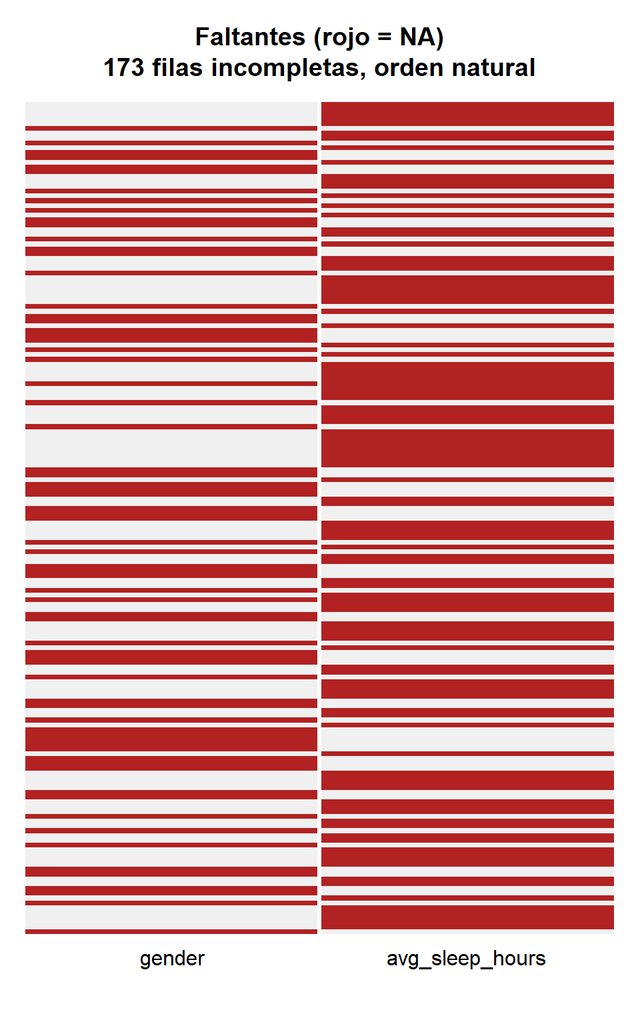

```r
inc <- !complete.cases(datos)
p   <- is.na(datos[inc, c("gender", "avg_sleep_hours")])

par(mar = c(3.5, 1, 4, 1))
image(t(p[nrow(p):1, ]), axes = FALSE, col = c("grey94", "firebrick"),
      main = "Faltantes (rojo = NA)\n173 filas incompletas, orden natural")
abline(v = 0.5, col = "white", lwd = 3)
axis(1, at = seq(0, 1, length.out = ncol(p)), labels = colnames(p),
     las = 1, cex.axis = 1.0, tick = FALSE, line = -0.6)
```

> **Describir:** el mapa de faltantes muestra las 173 filas incompletas y, en efecto, **dos filas tienen rojo en las dos columnas**.

> **Analizar:** queda confirmado que la diferencia entre 175 y 173 son esos dos participantes. No es un error de conteo: son dos personas a las que les falta el género **y** el sueño. **Decisión:** ninguna acción sobre ellas todavía; primero hay que decidir qué hacer con los faltantes en general.

Antes de decidir qué hacer con esos faltantes, una comprobación que no cuesta nada: ¿hay filas repetidas?

```r
sum(duplicated(datos))
```

```
#> [1] 0
```

```r
datos$participant_id[duplicated(datos$participant_id)]
```

```
#> character(0)
```

> **Describir:** cero filas duplicadas y cero identificadores repetidos.

> **Analizar:** cada fila es un participante distinto, así que no hay nada que deduplicar. **Decisión:** se sigue adelante.

## 2.3 Tratamiento de los faltantes

Ya sabemos dónde están. Ahora, cuánto pesan:

```r
round(mean(is.na(datos$avg_sleep_hours)) * 100, 2)
```

```
#> [1] 1.5
```

```r
round(mean(is.na(datos$gender)) * 100, 2)
```

```
#> [1] 1
```

```r
round(mean(!complete.cases(datos)) * 100, 1)
```

```
#> [1] 2.5
```

> **Describir:** `avg_sleep_hours` pierde el 1,5% de sus celdas y `gender` el 1,0%. En total, el 2,5% de las filas tiene al menos un `NA`.

> **Analizar:** son porcentajes pequeños, y eso es buena noticia, pero **no basta para decidir**. La pregunta no es cuánto falta, sino **por qué falta**: si quienes no respondieron son un grupo distinto del resto, borrarlos sesga el resultado aunque sean pocos.

**¿Qué podemos hacer con estos datos?** Recordemos la tabla vista en clase:

| Estrategia | Qué hace | El costo |
| --- | --- | --- |
| **Casos completos** | Borra la fila entera | Pierde $n$ y sesga si los faltantes no son aleatorios |
| **Por pares** | Usa lo que haya en cada par | La matriz de correlación puede dejar de ser definida positiva → **PCA imposible** |
| **Imputar por la media** | Rellena con el promedio | **Reduce artificialmente la varianza** y aplana las correlaciones |

Investiga, y encontrarás que hay tres “criterios” que explican por qué una celda puede estar vacía:

**MCAR (Missing Completely At Random):** “faltante completamente al azar”. El dato falta por una razón que no tiene nada que ver con nada.

**MAR (Missing At Random):** “faltante al azar”. El dato falta por algo relacionado con otras variables que sí se observaron.

**MNAR (Missing Not At Random):** “faltante no al azar”. El dato falta por el valor mismo que falta. Por ejemplo: los que duermen muy poquitas horas son justo los que no quieren reportarlo. Este es el peor caso, y no hay forma limpia de arreglarlo.

**¿Y por qué importa la diferencia?** Porque **borrar filas solo es correcto bajo MCAR**. Si borras bajo MAR o MNAR, el resultado queda sesgado. Ese es todo el motivo de la prueba que viene.

> **Analizar:** las dos variables no se tratan igual, y la razón es distinta en cada caso.
> - **`gender` se resuelve sin estadística.** El cuestionario ya ofrece la opción `"Prefer not to say"`, así que un `NA` equivale funcionalmente a una negativa a responder. **Decisión:** se rellena con esa categoría, que además conserva las otras 24 mediciones de esos 70 participantes.
> - **`avg_sleep_hours` sí exige una prueba.** Aquí no hay una categoría natural que absorba los faltantes, así que hay que determinar si la ausencia es aleatoria antes de borrar nada. **Decisión:** se somete a una prueba formal.

> Y una precisión que importa para lo que sigue: **la prueba solo puede descartar MCAR, o no descartarlo.** Distinguir MAR de MNAR es imposible en principio, porque ambos pueden generar exactamente los mismos datos observados.

Empezamos por el caso fácil, `gender`:

```r
gender_imputado <- is.na(datos$gender)
datos$gender[gender_imputado] <- "Prefer not to say"
table(datos$gender, useNA = "ifany")
```

```
#>
#>            Female              Male        Non-binary Prefer not to say
#>              3240              3261               276               223
```

```r
colSums(is.na(datos))
```

```
#>                      participant_id                                 age
#>                                   0                                   0
#>                              gender                          occupation
#>                                   0                                   0
#>                              region                  most_used_platform
#>                                   0                                   0
#>                platforms_used_count                  daily_screen_hours
#>                                   0                                   0
#>                 daily_notifications                      night_time_use
#>                                   0                                   0
#> minutes_to_first_check_after_waking                     primary_purpose
#>                                   0                                   0
#>                     avg_sleep_hours                 anxiety_score_0to27
#>                                 105                                   0
#>                low_mood_score_0to27             life_satisfaction_1to10
#>                                   0                                   0
#>                    loneliness_1to10                   self_esteem_1to10
#>                                   0                                   0
#>                          fomo_1to10             social_comparison_1to10
#>                                   0                                   0
#>     physical_activity_days_per_week             uses_screen_time_limits
#>                                   0                                   0
#>             attempted_digital_detox         seeks_mental_health_support
#>                                   0                                   0
#>                      wellbeing_band
#>                                   0
```

## 2.4 La prueba para `avg_sleep_hours`

Para `avg_sleep_hours` aplicamos una **prueba conjunta**, que combina una regresión logística con una prueba de razón de verosimilitud. Antes de verla, qué es cada pieza:

**¿Qué es cada cosa y qué se hará?**

> **Regresión logística:** Sirve para predecir un resultado de sí/no. La regresión estima cómo cambia la probabilidad de que sea “sí” según las otras variables.

> **Verosimilitud:** Es un número que dice “qué tan bien explica este modelo los datos que observamos”. Sí el resultado es más alto, indica que es mejor.

> **Razón de verosimilitud (LRT):** Acá se comparan dos modelos
> - Modelo 0 (nulo): predice la probabilidad de que falte usando nada (solo el promedio general (105/7000 = 1.5% para todos)).
> - Modelo 1: la predice usando todas las demás variables (las otras 13).

> Si el modelo 1 explica mucho mejor que el 0, entonces esas variables sí traen información sobre la ausencia (significa que no cumple con el criterio MCAR).

> La comparación se mide con **chi-cuadrado (χ²):** un número que resume cuánto mejoró. Más grande significa que mejoró más. Luego se convierte en un p-valor.

> **El p-valor:** responde una sola pregunta (si de verdad no hubiera ninguna diferencia, ¿qué tan probable sería ver una como la observada, solo por casualidad?). El criterio convencional es $p < 0.05$. Ojo con una cosa: **el p-valor no mide el tamaño del efecto**, así que un p-valor pequeño no significa que la diferencia sea importante.

Definimos quienes tienen el dato faltante (105 de 7000):

```r
na_s <- is.na(datos$avg_sleep_hours)
sum(na_s)
```

```
#> [1] 105
```

La idea es simple: **si la ausencia es aleatoria, esos 105 no deberían parecerse a nada en particular.** Comparémoslos entonces contra los otros 6895 en las trece variables numéricas.

```r
vars_num <- setdiff(names(datos)[sapply(datos, is.numeric)], "avg_sleep_hours")
round(sapply(vars_num, function(v)
  c(con_NA = mean(datos[[v]][na_s]), sin_NA = mean(datos[[v]][!na_s]))), 2)
```

```
#>          age platforms_used_count daily_screen_hours daily_notifications
#> con_NA 30.50                 3.50               3.01               48.94
#> sin_NA 29.23                 3.49               3.31               61.72
#>        minutes_to_first_check_after_waking anxiety_score_0to27
#> con_NA                               21.06               10.83
#> sin_NA                               19.99               11.39
#>        low_mood_score_0to27 life_satisfaction_1to10 loneliness_1to10
#> con_NA                 3.90                    6.95             4.41
#> sin_NA                 3.84                    6.96             4.68
#>        self_esteem_1to10 fomo_1to10 social_comparison_1to10
#> con_NA              6.06       4.70                    5.30
#> sin_NA              6.01       4.64                    5.32
#>        physical_activity_days_per_week
#> con_NA                            2.57
#> sin_NA                            2.81
```

> **Describir:** los dos grupos son casi idénticos en las trece variables. La diferencia más visible está en `daily_notifications`: 48,9 frente a 61,7, unas trece notificaciones menos.

> **Analizar:** trece comparaciones y doce salen planas. La de notificaciones es la única que llama la atención, y con trece pruebas simultáneas **alguna diferencia tiene que aparecer por puro azar**. **Decisión:** no decidir nada con esto; contrastarlo con una prueba que use las trece variables a la vez, para saber si esa diferencia aislada es real o es ruido.

Esa prueba conjunta compara dos modelos:

- `m0` es el modelo nulo: predice la ausencia usando nada, solo la tasa general de 1.5% para todos
- `m1` es el modelo completo: intenta predecir la ausencia usando las 13 variables. Aquí el resultado es “¿está vacía la celda de sueño?” (sí/no) para cada uno de los 7000 participantes.
- `anova(..., test = "LRT")` pregunta: ¿el modelo completo predice mejor que el nulo? Si sí, las variables traen información sobre quién falta (es decir, la ausencia no es aleatoria).

```r
m0 <- glm(na_s ~ 1, family = binomial)
m1 <- glm(na_s ~ ., data = datos[vars_num], family = binomial)
anova(m0, m1, test = "LRT")
```

|  | Resid. Df | Resid. Dev | Df | Deviance | Pr(>Chi) |
| --- | --- | --- | --- | --- | --- |
| 1 | 6999 | 1090.355 | NA | NA | NA |
| 2 | 6986 | 1075.005 | 13 | 15.35033 | 0.2859958 |

> **Describir:** la mejora es de 15,35 con 13 grados de libertad. El p-valor es 0,286.

> **Analizar:** lo primero que hay que mirar aquí no es el p-valor, sino **contra qué se compara esa mejora**. Si las trece variables no sirvieran para nada, por puro azar esperaríamos una mejora de aproximadamente 13 (una por cada variable añadida). La nuestra fue 15,35: apenas dos puntos más. Y el p-valor lo confirma: 0,286 significa que **una mejora así ocurriría el 29% de las veces aunque las variables no aportaran nada**.

> **Decisión:** se trata la ausencia como aleatoria y se aplica `listwise`, borrando las 105 filas.

> Y una cautela que conviene dejar escrita: **con 105 faltantes y 13 predictores, la prueba tiene potencia limitada**. No rechazar MCAR no es lo mismo que demostrarlo. Lo que sí podemos afirmar es que **no encontramos evidencia de que la ausencia sea sistemática**, y eso es suficiente para seguir.

> Así pues, podemos decir que la elección más acertada para tratar estos datos faltantes, es el uso de `listwise()` (Eliminar las 105 filas).

```r
completar_datos <- datos[complete.cases(datos), ]
dim(datos)
```

```
#> [1] 7000   25
```

```r
dim(completar_datos)
```

```
#> [1] 6895   25
```

```r
colSums(is.na(completar_datos))
```

```
#>                      participant_id                                 age
#>                                   0                                   0
#>                              gender                          occupation
#>                                   0                                   0
#>                              region                  most_used_platform
#>                                   0                                   0
#>                platforms_used_count                  daily_screen_hours
#>                                   0                                   0
#>                 daily_notifications                      night_time_use
#>                                   0                                   0
#> minutes_to_first_check_after_waking                     primary_purpose
#>                                   0                                   0
#>                     avg_sleep_hours                 anxiety_score_0to27
#>                                   0                                   0
#>                low_mood_score_0to27             life_satisfaction_1to10
#>                                   0                                   0
#>                    loneliness_1to10                   self_esteem_1to10
#>                                   0                                   0
#>                          fomo_1to10             social_comparison_1to10
#>                                   0                                   0
#>     physical_activity_days_per_week             uses_screen_time_limits
#>                                   0                                   0
#>             attempted_digital_detox         seeks_mental_health_support
#>                                   0                                   0
#>                      wellbeing_band
#>                                   0
```

# 3 Análisis univariado

## 3.1 Análisis univariado: Variables numéricas

Antes de proceder con el análisis univariado, debemos identificar las principales características de cada varaible (en este caso particular, de las numéricas).

La idea a continuación es realizar un `summary()` con el fin de identificar las principales características de nuestras variables numéricas (como la media, la desviación, el mínimo, etc), sin embargo, por cuestiones prácticas, decidimos agregar una columna `sesgo`, la cual nos ayudará a medir la asimetría en una distribución, facilitando el análisis de los gráficos univariados.

```r
num <- completar_datos[, sapply(completar_datos, is.numeric)]
str(num)
```

```
#> 'data.frame':    6895 obs. of  14 variables:
#>  $ age                                : int  33 23 56 13 36 28 25 40 13 19 ...
#>  $ platforms_used_count               : int  8 8 1 4 5 5 6 2 1 1 ...
#>  $ daily_screen_hours                 : num  3.2 4.5 5.3 3.4 5.8 3.6 3.5 2 4.2 2 ...
#>  $ daily_notifications                : int  172 38 74 49 227 29 55 10 106 34 ...
#>  $ minutes_to_first_check_after_waking: int  25 26 12 21 19 11 38 28 18 51 ...
#>  $ avg_sleep_hours                    : num  8.7 7.3 7 7 6.7 5 8.3 8 8.1 7.3 ...
#>  $ anxiety_score_0to27                : int  17 18 12 13 15 8 13 7 6 12 ...
#>  $ low_mood_score_0to27               : int  0 2 6 0 1 4 8 0 11 0 ...
#>  $ life_satisfaction_1to10            : int  9 7 8 10 4 7 7 7 6 9 ...
#>  $ loneliness_1to10                   : int  6 5 7 6 6 9 1 8 6 6 ...
#>  $ self_esteem_1to10                  : int  4 8 3 6 8 5 7 9 6 9 ...
#>  $ fomo_1to10                         : int  6 5 2 1 7 4 7 4 4 6 ...
#>  $ social_comparison_1to10            : int  8 8 3 5 9 3 3 7 10 7 ...
#>  $ physical_activity_days_per_week    : int  4 4 5 4 3 3 3 3 4 0 ...
```

```r
sesgo <- function(x) {
  x <- x[!is.na(x)]
  m <- mean(x); n <- length(x)
  (sum((x - m)^3) / n) / ((sum((x - m)^2) / n))^1.5
}

atipicos <- function(x) {
  q <- quantile(x, c(.25, .75)); ric <- diff(q)
  sum(x < q[1] - 1.5*ric | x > q[2] + 1.5*ric)
}

descriptivos <- data.frame(
  min      = round(sapply(num, min), 2),
  q1       = round(sapply(num, quantile, 0.25), 2),
  mediana  = round(sapply(num, median), 2),
  media    = round(sapply(num, mean), 2),
  q3       = round(sapply(num, quantile, 0.75), 2),
  max      = round(sapply(num, max), 2),
  desv     = round(sapply(num, sd), 2),
  sesgo    = round(sapply(num, sesgo), 2),
  atipicos = sapply(num, atipicos)
)
descriptivos
```

|  | min | q1 | mediana | media | q3 | max | desv | sesgo | atipicos |
| --- | --- | --- | --- | --- | --- | --- | --- | --- | --- |
| age | 13.0 | 22.0 | 29 | 29.23 | 36.0 | 71 | 9.57 | 0.27 | 17 |
| platforms_used_count | 1.0 | 2.0 | 3 | 3.49 | 5.0 | 8 | 1.76 | 0.50 | 0 |
| daily_screen_hours | 0.2 | 1.9 | 3 | 3.31 | 4.3 | 14 | 1.88 | 1.06 | 170 |
| daily_notifications | 5.0 | 24.0 | 46 | 61.72 | 83.0 | 400 | 54.91 | 2.07 | 339 |
| minutes_to_first_check_after_waking | 0.0 | 10.0 | 17 | 19.99 | 27.0 | 111 | 13.96 | 1.37 | 221 |
| avg_sleep_hours | 3.8 | 6.4 | 7 | 6.96 | 7.6 | 10 | 0.87 | -0.05 | 48 |
| anxiety_score_0to27 | 0.0 | 8.0 | 11 | 11.39 | 14.0 | 27 | 4.78 | 0.20 | 65 |
| low_mood_score_0to27 | 0.0 | 0.0 | 3 | 3.84 | 6.0 | 19 | 3.54 | 0.75 | 17 |
| life_satisfaction_1to10 | 1.0 | 6.0 | 7 | 6.96 | 8.0 | 10 | 1.61 | -0.20 | 26 |
| loneliness_1to10 | 1.0 | 3.0 | 5 | 4.68 | 6.0 | 10 | 2.09 | 0.21 | 0 |

[output cut: 4 more lines]

## 3.2 Distribuciones de cada variable numérica

### 3.2.1 Edad (`age`)

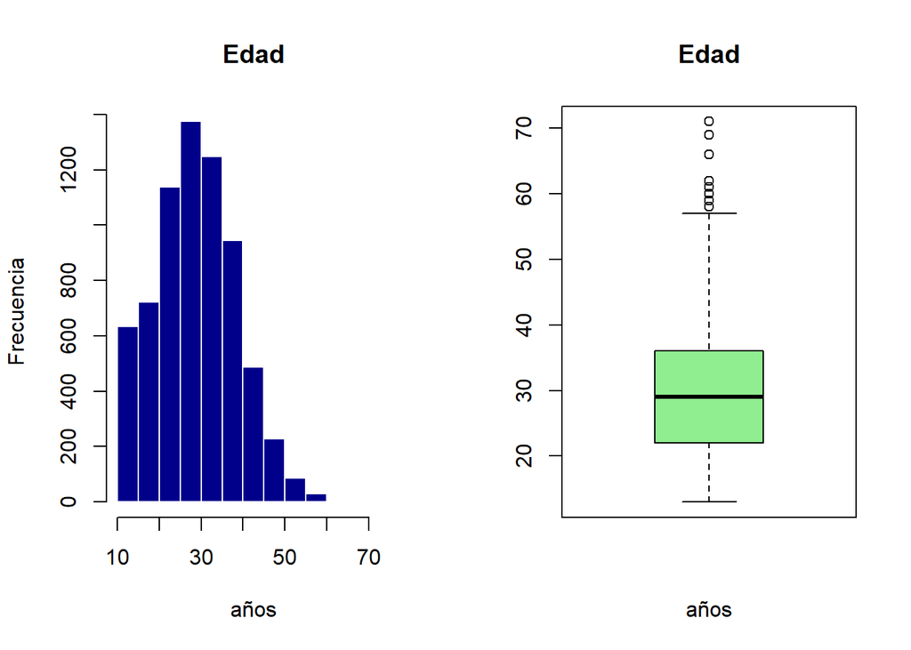

```r
op <- par(mfrow = c(1, 2))
hist(num$age, breaks = 20, main = "Edad", xlab = "años", ylab = "Frecuencia",
     col = "darkblue", border = "white")
boxplot(num$age, horizontal = FALSE, main = "Edad", xlab = "años",
        col = "lightgreen")
```

```r
par(op)
```

> **Describir:** la distribución es casi simétrica (0,27), y la media y la mediana coinciden: 29,23 frente a 29. El boxplot marca 17 casos atípicos, todos hacia arriba.

> **Analizar:** esos 17 no son un problema, son simplemente los participantes mayores. En una muestra de 13 a 71 años, quien tiene 60 queda fuera del rango intercuartílico por pura aritmética, no porque su dato sea raro. Aquí la media sí representa al participante típico, así que se puede usar sin miedo.

> Conviene retener un dato desde ya: **la edad no se relaciona con el tiempo de pantalla** (r = 0,01). Eso descarta de entrada una de las explicaciones más intuitivas del uso intensivo (que sea cosa de los jóvenes) antes de que lleguemos al análisis multivariado.

### 3.2.2 Plataformas usadas (`platforms_used_count`)

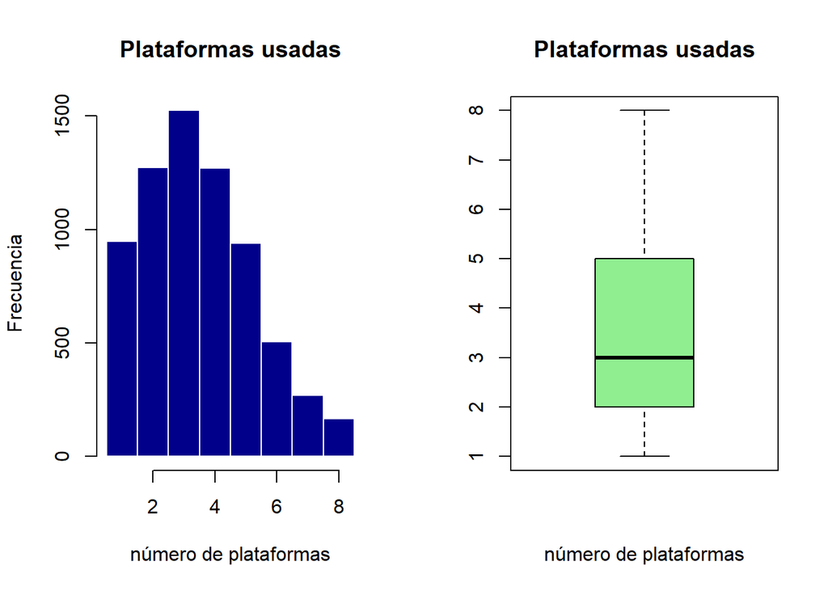

```r
op <- par(mfrow = c(1, 2))
hist(num$platforms_used_count, breaks = 0.5:8.5, main = "Plataformas usadas",
     xlab = "número de plataformas", ylab = "Frecuencia",
     col = "darkblue", border = "white")
boxplot(num$platforms_used_count, horizontal = FALSE, main = "Plataformas usadas",
        xlab = "número de plataformas", col = "lightgreen")
```

```r
par(op)
```

> **Describir:** la distribución se ve escalonada en lugar de curva, con la mayoría entre 2 y 5 plataformas. La media es 3,49; la mediana, 3. El boxplot no marca ningún atípico.

> **Analizar:** se ve escalonada porque **es un recuento, no una medición continua**: solo puede valer 1, 2, 3… hasta 8. Por eso la media de 3,49 describe al grupo pero no a nadie en particular (no existe alguien que use tres plataformas y media). Y el boxplot no marca atípicos no porque la variable sea homogénea, sino porque al estar acotada entre 1 y 8 su rango intercuartílico es tan ancho en proporción que ningún valor alcanza a quedar fuera. **Decisión:** tratarla como numérica en los cálculos, pero leerla siempre en valores enteros.

> Otro dato para más adelante: el número de plataformas **no se asocia con el tiempo de pantalla** (r = −0,01). Cuántas redes usa alguien no dice nada sobre cuánto tiempo pasa en ellas.

### 3.2.3 Horas diarias de pantalla (`daily_screen_hours`)

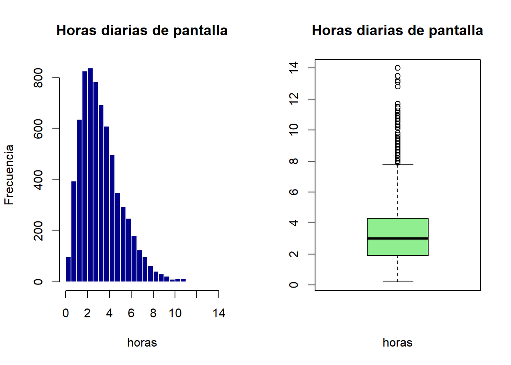

```r
op <- par(mfrow = c(1, 2))
hist(num$daily_screen_hours, breaks = 20, main = "Horas diarias de pantalla",
     xlab = "horas", ylab = "Frecuencia", col = "darkblue", border = "white")
boxplot(num$daily_screen_hours, horizontal = FALSE, main = "Horas diarias de pantalla",
        xlab = "horas", col = "lightgreen")
```

```r
par(op)
```

> **Describir:** el grueso de la muestra se concentra entre 1 y 4 horas, con una cola hacia la derecha que llega hasta las 14. La mediana es 3; la media, 3,31. El boxplot marca 170 casos atípicos.

> **Analizar:** esta es nuestra variable objetivo, y va a condicionar todo lo que venga después. Dos cosas:
> - **El promedio se queda corto.** La media está en el percentil 58, así que **casi la mitad de la muestra (42%) usa más pantalla que el “promedio”**. Reportar 3,31 horas como cifra representativa describiría a una minoría. **Decisión:** reportar siempre la mediana (3 horas) junto a la media.
> - **Su asimetría se contagia.** Como esta variable es el eje de casi todas las asociaciones del proyecto, su cola pesada se va a propagar a toda la matriz de correlaciones y, más adelante, a los métodos que usen distancias. **Para el informe:** tenerlo presente cuando empiecen a aparecer casos que parezcan raros.

### 3.2.4 Notificaciones diarias (`daily_notifications`)

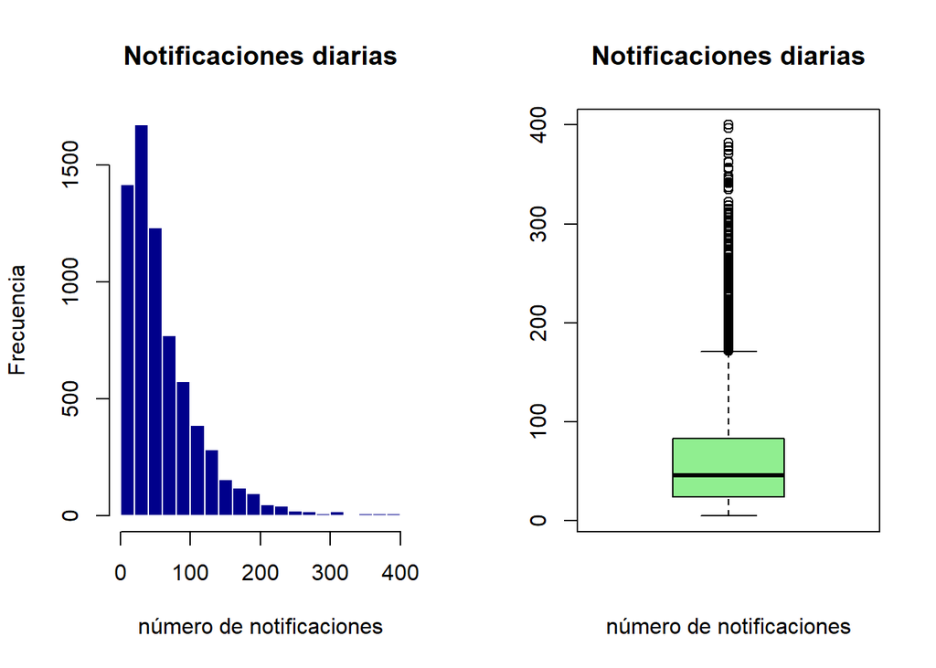

```r
op <- par(mfrow = c(1, 2))
hist(num$daily_notifications, breaks = 20, main = "Notificaciones diarias",
     xlab = "número de notificaciones", ylab = "Frecuencia",
     col = "darkblue", border = "white")
boxplot(num$daily_notifications, horizontal = FALSE, main = "Notificaciones diarias",
        xlab = "número de notificaciones", col = "lightgreen")
```

```r
par(op)
```

> **Describir:** el pico está cerca de 25 notificaciones y de ahí todo cae hacia la derecha hasta 400. La mediana es 46; la media, 61,7. El boxplot marca **339 casos atípicos**, todos por arriba.

> **Analizar:** aquí no hay una población, hay **dos**. La mayoría de la gente vive entre 20 y 80 notificaciones al día, y un grupo pequeño se mueve en un orden de magnitud distinto. Esa convivencia es la que vuelve incómoda a esta variable: casi todas las herramientas que vienen de aquí en adelante suponen que los datos se parecen a una campana, y esto no lo es.
> - **El promedio no la representa.** La media está en el percentil 63, o sea que **más de un tercio de la muestra recibe más notificaciones que el “promedio”**. Cuando el promedio deja por debajo a un tercio de la gente, no está describiendo a nadie. **Decisión:** reportar la mediana junto a la media, nunca la media sola.
> - **Sus atípicos no son errores.** Son usuarios reales con un uso intenso, no celdas mal escritas. Comprobamos además que **no cambian la conclusión del proyecto**: la correlación con las horas de pantalla es 0,61, y quitando los 339 casos baja apenas a 0,56. **Decisión:** se quedan.
> - **Y nos va a dar trabajo después.** Cuando lleguemos a Mahalanobis y a componentes principales, buena parte de los casos que salgan como raros van a venir de aquí. **Para el informe:** mejor advertirlo ahora que explicarlo cuando ya aparezca.

### 3.2.5 Minutos hasta revisar el celular al despertar (`minutes_to_first_check_after_waking`)

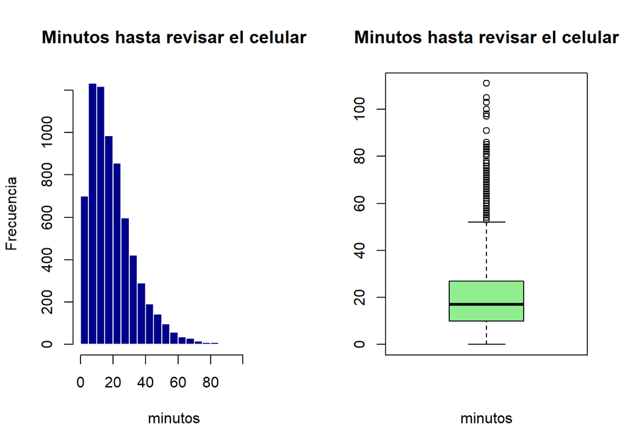

```r
op <- par(mfrow = c(1, 2))
hist(num$minutes_to_first_check_after_waking, breaks = 20,
     main = "Minutos hasta revisar el celular", xlab = "minutos",
     ylab = "Frecuencia", col = "darkblue", border = "white")
boxplot(num$minutes_to_first_check_after_waking, horizontal = FALSE,
        main = "Minutos hasta revisar el celular", xlab = "minutos",
        col = "lightgreen")
```

```r
par(op)
```

> **Describir:** la mayoría revisa el celular en los primeros veinte minutos del día, con una cola que se estira hasta los 111. La mediana es 17; la media, 20. El boxplot marca 221 atípicos.

> **Analizar:** como en notificaciones, la media vuelve a quedar por encima del valor típico (está en el percentil 58). Pero lo llamativo de esta variable no es su forma, sino lo que **no** se relaciona.

> **Su independencia del tiempo de pantalla es total** (r = 0,01). Revisar el celular apenas despierto no guarda ninguna relación con cuántas horas se usa después. Son dos comportamientos que la intuición agruparía como “uso problemático” y que los datos separan. **Para el informe:** cuando lleguemos a la estructura de correlaciones, esta va a quedar por fuera, y no es un error de cálculo.

### 3.2.6 Horas de sueño promedio (`avg_sleep_hours`)

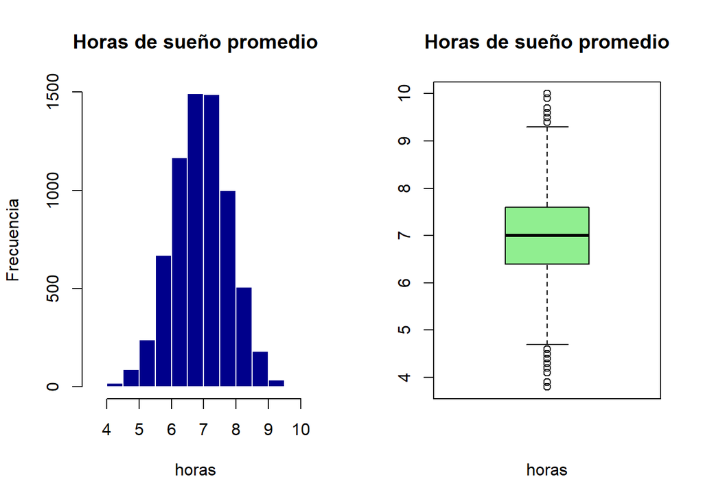

```r
op <- par(mfrow = c(1, 2))
hist(num$avg_sleep_hours, breaks = 20, main = "Horas de sueño promedio",
     xlab = "horas", ylab = "Frecuencia", col = "darkblue", border = "white")
boxplot(num$avg_sleep_hours, horizontal = FALSE, main = "Horas de sueño promedio",
        xlab = "horas", col = "lightgreen")
```

```r
par(op)
```

> **Describir:** es la variable con la dispersión más baja de toda la matriz (0,87 horas) y prácticamente simétrica (−0,05). Media 6,96 y mediana 7: coinciden. La mayoría duerme entre 6,4 y 7,6 horas. El boxplot marca 48 atípicos.

> **Decisión:** entra sin transformaciones en los métodos que asuman normalidad. Y guardamos su asociación con la pantalla, que es la más fuerte de todas las negativas: **a más pantalla, menos sueño** (−0,38).

### 3.2.7 Ansiedad (`anxiety_score_0to27`)

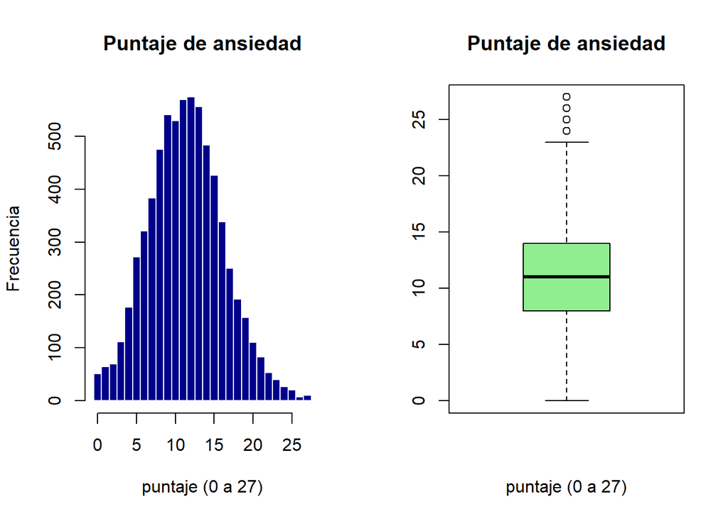

```r
op <- par(mfrow = c(1, 2))
hist(num$anxiety_score_0to27, breaks = -0.5:27.5, main = "Puntaje de ansiedad",
     xlab = "puntaje (0 a 27)", ylab = "Frecuencia",
     col = "darkblue", border = "white")
boxplot(num$anxiety_score_0to27, horizontal = FALSE, main = "Puntaje de ansiedad",
        xlab = "puntaje (0 a 27)", col = "lightgreen")
```

```r
par(op)
```

> **Describir:** la distribución es prácticamente simétrica (0,20) y la media y la mediana casi coinciden: 11,39 frente a 11. El boxplot marca 65 casos atípicos, los puntajes altos.

> **Analizar:** aquí la media sí representa, así que se puede usar sin reservas. Y los 65 atípicos no son casos anómalos: son la cola natural de una escala de 28 puntos. Alguien con 27 sobre 27 es un extremo, pero es un extremo posible.

> Esta es una de las variables que mejor sostiene el hallazgo central del proyecto: **su correlación con el tiempo de pantalla es 0,53, la segunda más alta**, y resiste bien la poda de atípicos (baja apenas a 0,50). Es decir, **la asociación no depende de unos pocos casos extremos: se sostiene en toda la muestra.**

### 3.2.8 Ánimo bajo (`low_mood_score_0to27`)

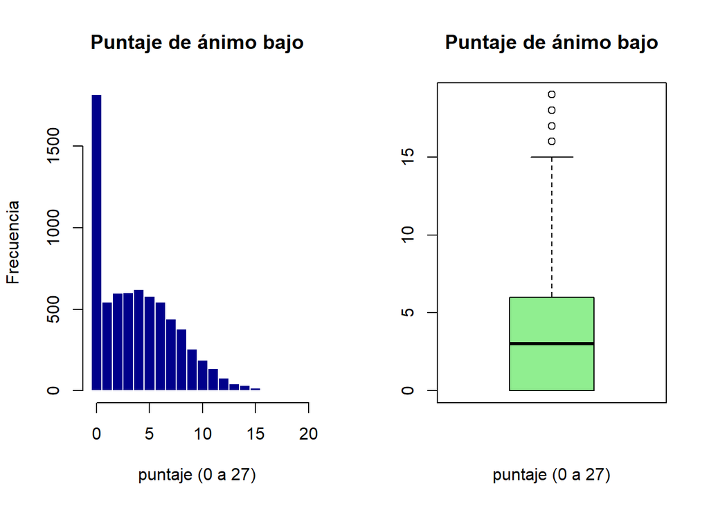

```r
op <- par(mfrow = c(1, 2))
hist(num$low_mood_score_0to27, breaks = -0.5:19.5, main = "Puntaje de ánimo bajo",
     xlab = "puntaje (0 a 27)", ylab = "Frecuencia",
     col = "darkblue", border = "white")
boxplot(num$low_mood_score_0to27, horizontal = FALSE, main = "Puntaje de ánimo bajo",
        xlab = "puntaje (0 a 27)", col = "lightgreen")
```

```r
par(op)
```

> **Describir:** el primer cuartil es cero y la masa de datos se acumula en los valores bajos, con una cola que llega hasta 19. La mediana es 3; la media, 3,84. Asimetría 0,75.

> **Analizar:** aquí hay un **efecto piso**, y tiene una consecuencia que conviene decir en voz alta: **al menos una cuarta parte de la muestra no reporta ningún síntoma de ánimo bajo**. Eso significa que la media (3,84) no describe a nadie: el participante típico está en 3, y un cuarto de la muestra está en 0.

> **Decisión:** reportar la mediana, y mencionar explícitamente el porcentaje sin síntomas, que es el dato más informativo de esta variable. Su correlación con la pantalla (−0,36) es de las más estables: quitarle sus 17 atípicos la mueve una milésima.

### 3.2.9 Satisfacción con la vida (`life_satisfaction_1to10`)

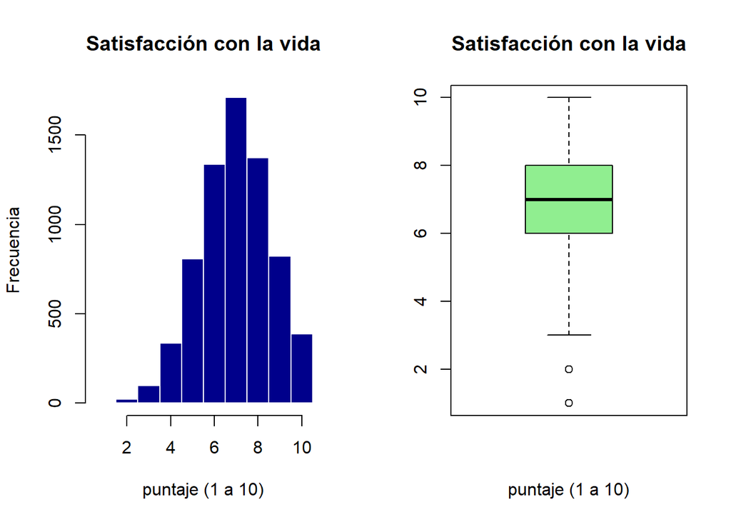

```r
op <- par(mfrow = c(1, 2))
hist(num$life_satisfaction_1to10, breaks = 0.5:10.5, main = "Satisfacción con la vida",
     xlab = "puntaje (1 a 10)", ylab = "Frecuencia",
     col = "darkblue", border = "white")
boxplot(num$life_satisfaction_1to10, horizontal = FALSE,
        main = "Satisfacción con la vida", xlab = "puntaje (1 a 10)",
        col = "lightgreen")
```

```r
par(op)
```

> **Analizar:** la asimetría negativa se traduce en algo que conviene no pasar por alto: **la muestra está mayoritariamente satisfecha**. La media está en el percentil 38, o sea que **cerca de dos tercios de los participantes se declaran más satisfechos que el promedio**.

> Es el espejo exacto de `daily_notifications`. Allí el promedio **exageraba** el fenómeno; aquí lo **minimiza**. La conclusión de fondo es la misma (el promedio por sí solo induce a error) pero en direcciones opuestas, y eso refuerza el argumento de acompañarlo siempre de la mediana. Su correlación con la pantalla es −0,36.

### 3.2.10 Soledad (`loneliness_1to10`)

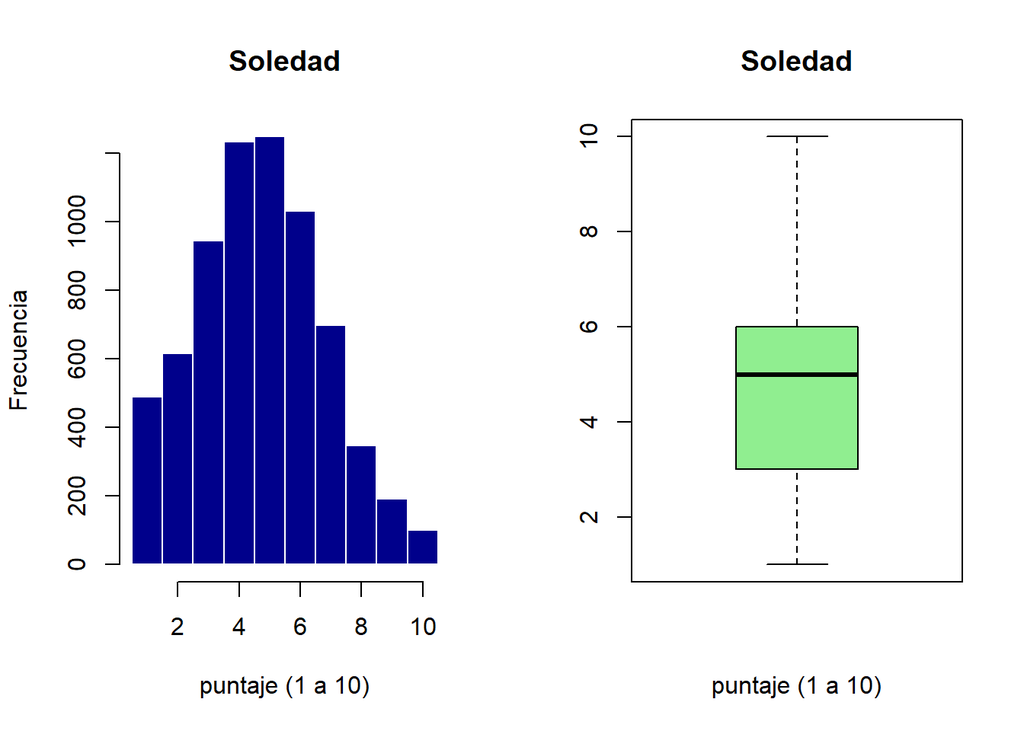

```r
op <- par(mfrow = c(1, 2))
hist(num$loneliness_1to10, breaks = 0.5:10.5, main = "Soledad",
     xlab = "puntaje (1 a 10)", ylab = "Frecuencia",
     col = "darkblue", border = "white")
boxplot(num$loneliness_1to10, horizontal = FALSE, main = "Soledad",
        xlab = "puntaje (1 a 10)", col = "lightgreen")
```

```r
par(op)
```

> **Describir:** la distribución es prácticamente simétrica (0,21), con media 4,68 y mediana 5. **El boxplot no marca ningún atípico.**

> **Analizar:** esa ausencia de atípicos merece una frase, porque no siempre significa lo mismo. Aquí es sencillamente que **todos los valores son igualmente plausibles**: en una escala de 1 a 10 sin concentración en los extremos, el rango intercuartílico cubre casi toda la escala y ningún punto queda fuera. El boxplot no está diciendo “no hay nada que reportar”, está diciendo “esta variable se comporta como debe”.

> **Decisión:** entra sin reservas en cualquier método. Su asociación con la pantalla (0,34) es moderada y muy estable.

### 3.2.11 Autoestima (`self_esteem_1to10`)

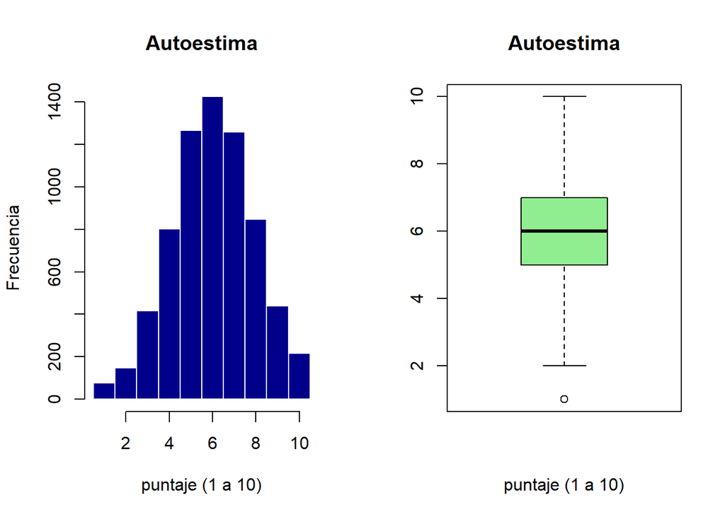

```r
op <- par(mfrow = c(1, 2))
hist(num$self_esteem_1to10, breaks = 0.5:10.5, main = "Autoestima",
     xlab = "puntaje (1 a 10)", ylab = "Frecuencia",
     col = "darkblue", border = "white")
boxplot(num$self_esteem_1to10, horizontal = FALSE, main = "Autoestima",
        xlab = "puntaje (1 a 10)", col = "lightgreen")
```

```r
par(op)
```

> **Describir:** la distribución es simétrica (−0,10), con media 6,01 y mediana 6. La dispersión es de las más bajas de la matriz. El boxplot marca 77 atípicos, los casos de autoestima muy baja.

> **Analizar:** es una de las variables mejor comportadas del conjunto, y eso tiene una consecuencia concreta: **es utilizable sin reservas en métodos que asumen normalidad**, cosa que no ocurre con ninguna de las variables de pantalla. Sus 77 atípicos son puntajes de 1 sobre 10: plausibles, no anómalos.

> **Decisión:** en la estandarización ni gana ni pierde protagonismo, así que entra en pie de igualdad con las demás escalas de 1 a 10.

### 3.2.12 FOMO (`fomo_1to10`)

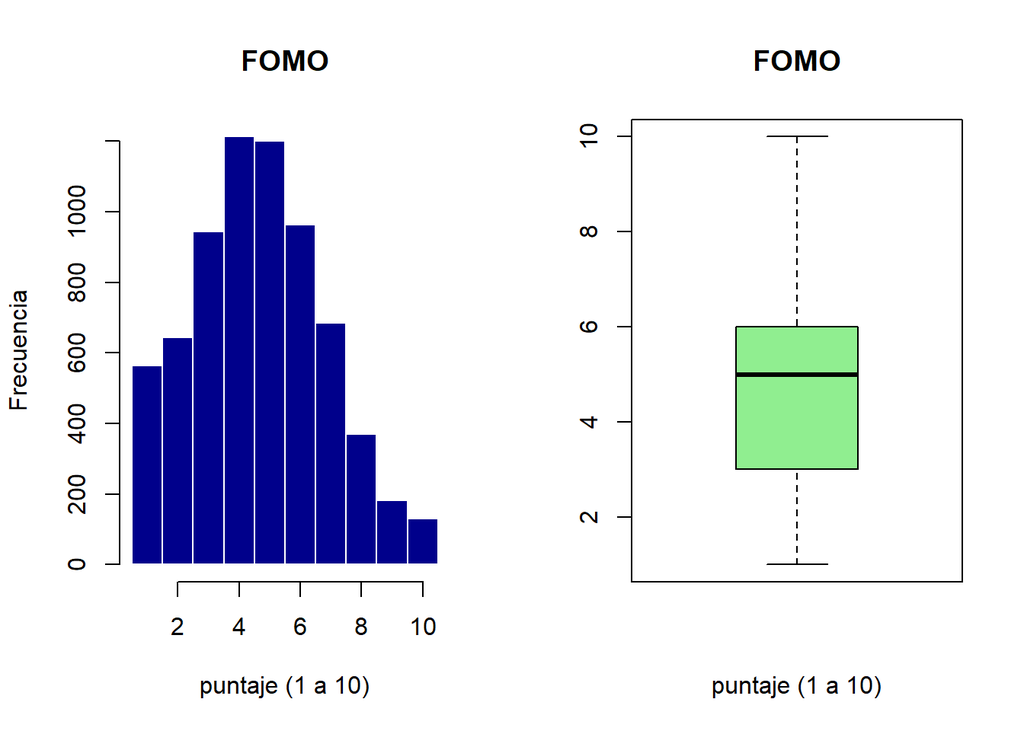

```r
op <- par(mfrow = c(1, 2))
hist(num$fomo_1to10, breaks = 0.5:10.5, main = "FOMO",
     xlab = "puntaje (1 a 10)", ylab = "Frecuencia",
     col = "darkblue", border = "white")
boxplot(num$fomo_1to10, horizontal = FALSE, main = "FOMO",
        xlab = "puntaje (1 a 10)", col = "lightgreen")
```

```r
par(op)
```

> **Describir:** prácticamente simétrica (0,24), sin ningún atípico, con media 4,64 y mediana 5.

> **Analizar:** pertenece al grupo de variables limpias, junto con la soledad y la comparación social. Y sin embargo **su correlación con el tiempo de pantalla es 0,43: la tercera más alta del dataset**, por encima de las otras dos.

> Eso la vuelve una de las asociaciones más sólidas del proyecto: fuerte, y sin el menor indicio de estar impulsada por casos extremos (porque no tiene ninguno). **Para el informe:** cuando alguien pregunte si la relación entre pantalla y bienestar depende de unos pocos casos raros, esta variable es la mejor respuesta.

### 3.2.13 Comparación social (`social_comparison_1to10`)

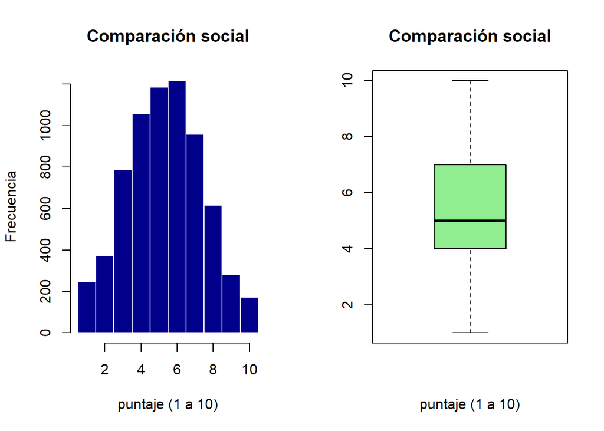

```r
op <- par(mfrow = c(1, 2))
hist(num$social_comparison_1to10, breaks = 0.5:10.5, main = "Comparación social",
     xlab = "puntaje (1 a 10)", ylab = "Frecuencia",
     col = "darkblue", border = "white")
boxplot(num$social_comparison_1to10, horizontal = FALSE, main = "Comparación social",
        xlab = "puntaje (1 a 10)", col = "lightgreen")
```

```r
par(op)
```

> **Describir:** asimetría 0,03 y media y mediana prácticamente idénticas (5,32 frente a 5). Sin atípicos y sin acumulación en los extremos. Es la distribución más simétrica de **todo el dataset**.

> **Analizar:** si hubiera que elegir una variable “bien comportada” del conjunto, sería esta. Y esa limpieza no es solo una curiosidad: la convierte en **el mejor punto de referencia del proyecto**. Si un procedimiento estadístico falla con `social_comparison`, el problema está en el método y no en los datos (eso nos va a servir más adelante para distinguir un error nuestro de un dato problemático).

> **Decisión:** se usa como control. Su asociación con la pantalla es moderada (0,35).

### 3.2.14 Actividad física (`physical_activity_days_per_week`)

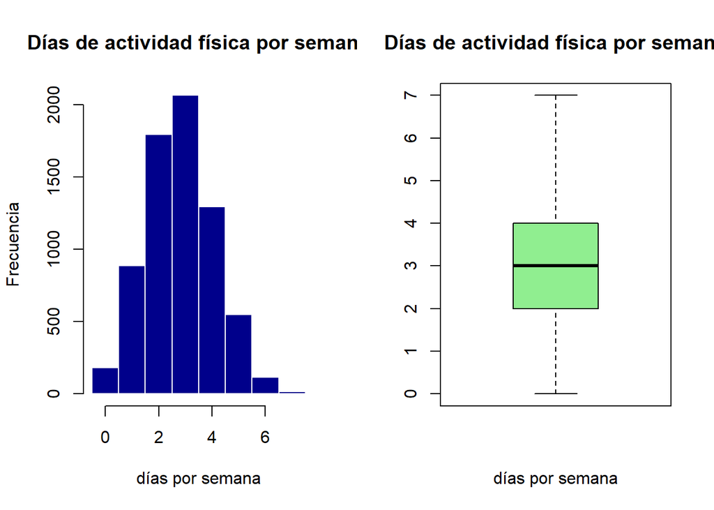

```r
op <- par(mfrow = c(1, 2))
hist(num$physical_activity_days_per_week, breaks = -0.5:7.5,
     main = "Días de actividad física por semana", xlab = "días por semana",
     ylab = "Frecuencia", col = "darkblue", border = "white")
boxplot(num$physical_activity_days_per_week, horizontal = FALSE,
        main = "Días de actividad física por semana", xlab = "días por semana",
        col = "lightgreen")
```

```r
par(op)
```

> **Describir:** recuento acotado de 0 a 7 días, con el grueso entre 2 y 4. Asimetría 0,17 y **ningún atípico**.

> **Analizar:** como en plataformas, los ocho valores posibles explican que el boxplot no marque nada: el rango intercuartílico (de 2 a 4) es tan ancho en proporción al recorrido total que ningún día queda lo bastante lejos.

> Pero lo que importa de esta variable es otra cosa: **su correlación con el tiempo de pantalla es 0,004. Ninguna.** El uso de pantalla y la actividad física se comportan como fenómenos separados en estos datos. **Para el informe:** eso descarta otra de las explicaciones intuitivas (que el sedentarismo digital desplace al ejercicio) y deja el campo libre a las variables psicológicas, que sí concentran todas las asociaciones relevantes.

Después de las catorce, el patrón es claro y se puede decir en dos frases:

- Las variables de **comportamiento de pantalla** (`daily_notifications`, `daily_screen_hours`, `minutes_to_first_check_after_waking`) son las asimétricas. Todas tienen colas largas hacia la derecha, porque reflejan comportamientos donde unos pocos usuarios son extremos.
- Las de **bienestar psicológico** tipo Likert (`self_esteem_1to10`, `social_comparison_1to10`, `fomo_1to10`, `loneliness_1to10`) y `avg_sleep_hours` son casi simétricas. Se comportan como escalas diseñadas para capturar un rango normal de respuesta.

Y una advertencia que vale para todo el informe: **estos datos son simulados**. Las formas que acabamos de describir reflejan el diseño del generador, no leyes del comportamiento humano. Cuando decimos que una escala “está bien diseñada” o que una variable “se comporta como debe”, hablamos de la estructura del dataset, no de personas reales.

**Nuestra variable objetivo será `daily_screen_hours`**, y no por casualidad: es la que articula casi todas las relaciones que vamos a encontrar, y la pregunta del proyecto es justamente de qué depende.

## 3.3 Análisis univariado: Variables categóricas

Las diez variables categóricas completan la descripción de la muestra. Sus frecuencias ya se revisaron en la sección de identificación de anomalías, donde sirvieron para detectar los valores faltantes y los niveles inesperados; aquí las presentamos sobre los datos ya tratados, con la distribución final de la muestra.

### 3.3.1 Género (`gender`)

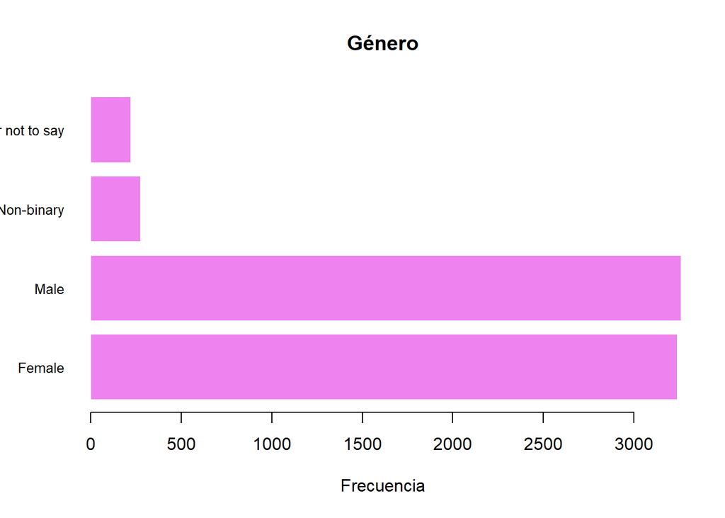

```r
barplot(table(datos$gender), horiz = TRUE, las = 1, main = "Género",
        xlab = "Frecuencia", col = "violet", border = "white", cex.names = 0.8)
```

### 3.3.2 Ocupación (`occupation`)

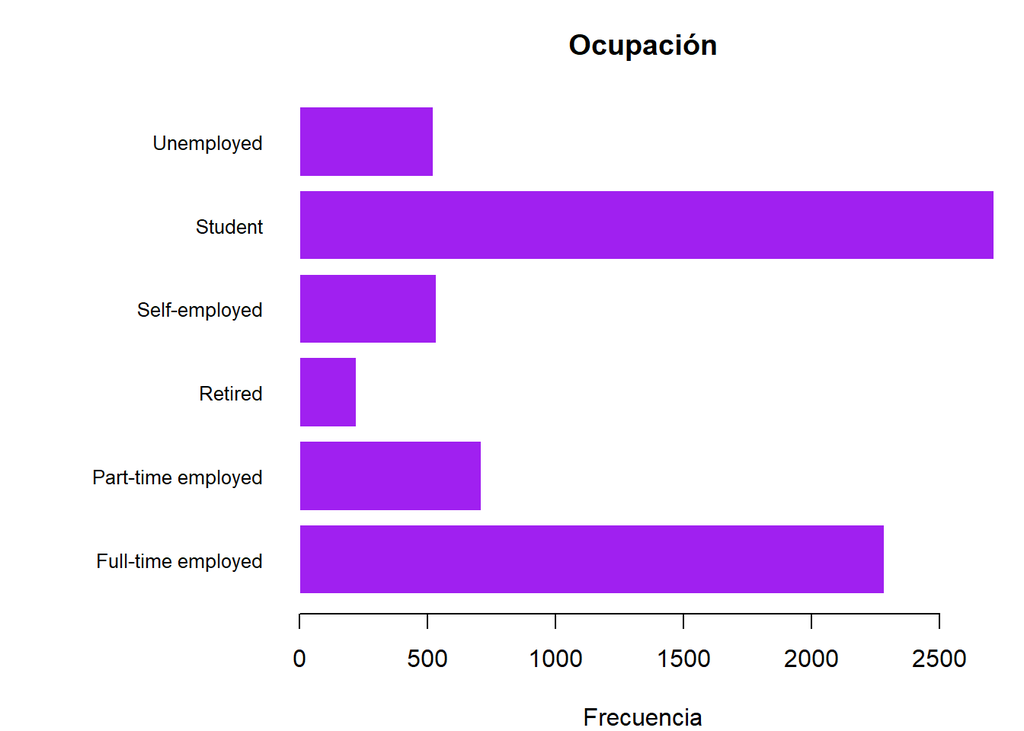

```r
op <- par(mar = c(4, 10, 3, 1))
barplot(table(datos$occupation), horiz = TRUE, las = 1, main = "Ocupación",
        xlab = "Frecuencia", col = "purple", border = "white", cex.names = 0.8)
```

```r
par(op)
```

### 3.3.3 Región (`region`)

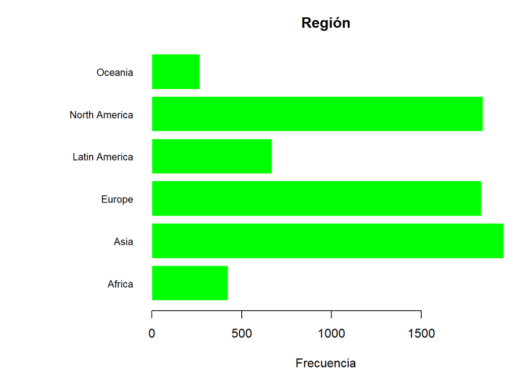

```r
op <- par(mar = c(4, 10, 3, 1))
barplot(table(datos$region), horiz = TRUE, las = 1, main = "Región",
        xlab = "Frecuencia", col = "green", border = "white", cex.names = 0.8)
```

```r
par(op)
```

### 3.3.4 Plataforma más usada (`most_used_platform`)

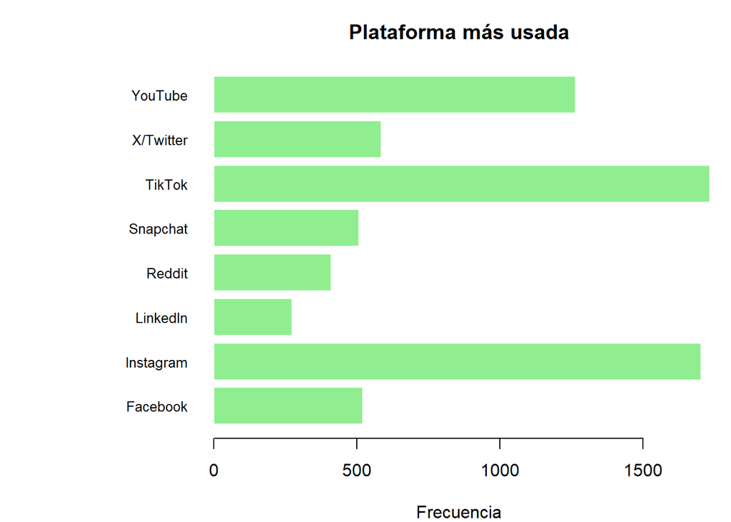

```r
op <- par(mar = c(4, 10, 3, 1))
barplot(table(datos$most_used_platform), horiz = TRUE, las = 1,
        main = "Plataforma más usada", xlab = "Frecuencia",
        col = "lightgreen", border = "white", cex.names = 0.8)
```

```r
par(op)
```

### 3.3.5 Uso nocturno (`night_time_use`)

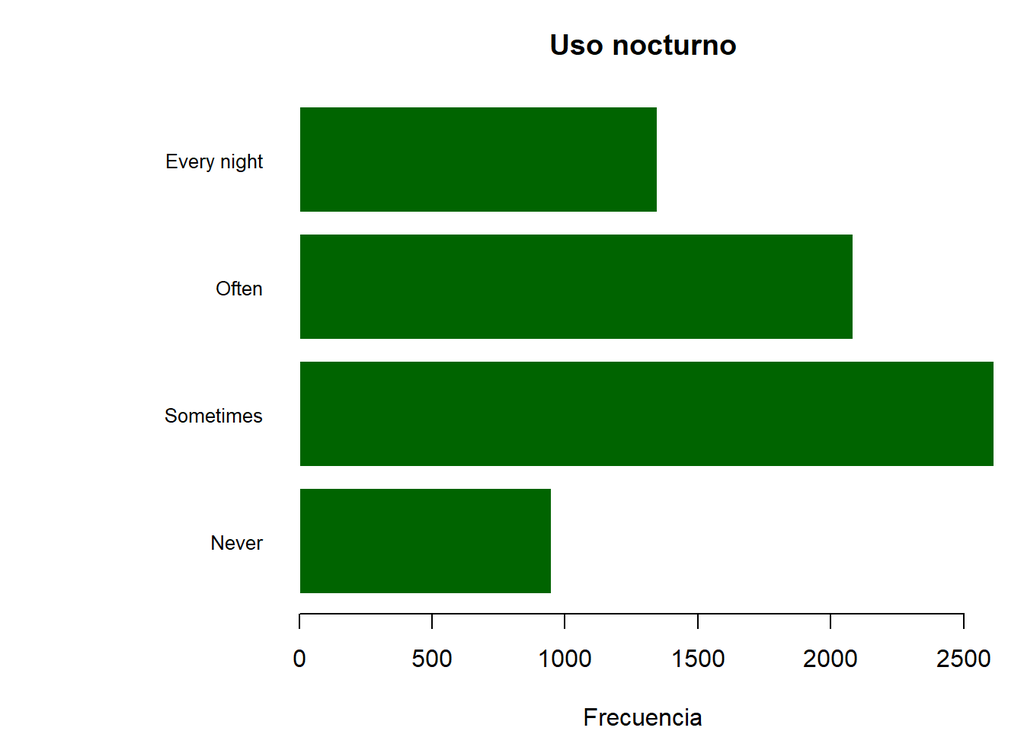

```r
op <- par(mar = c(4, 10, 3, 1))
barplot(table(datos$night_time_use), horiz = TRUE, las = 1,
        main = "Uso nocturno", xlab = "Frecuencia",
        col = "darkgreen", border = "white", cex.names = 0.8)
```

```r
par(op)
```

### 3.3.6 Propósito principal (`primary_purpose`)

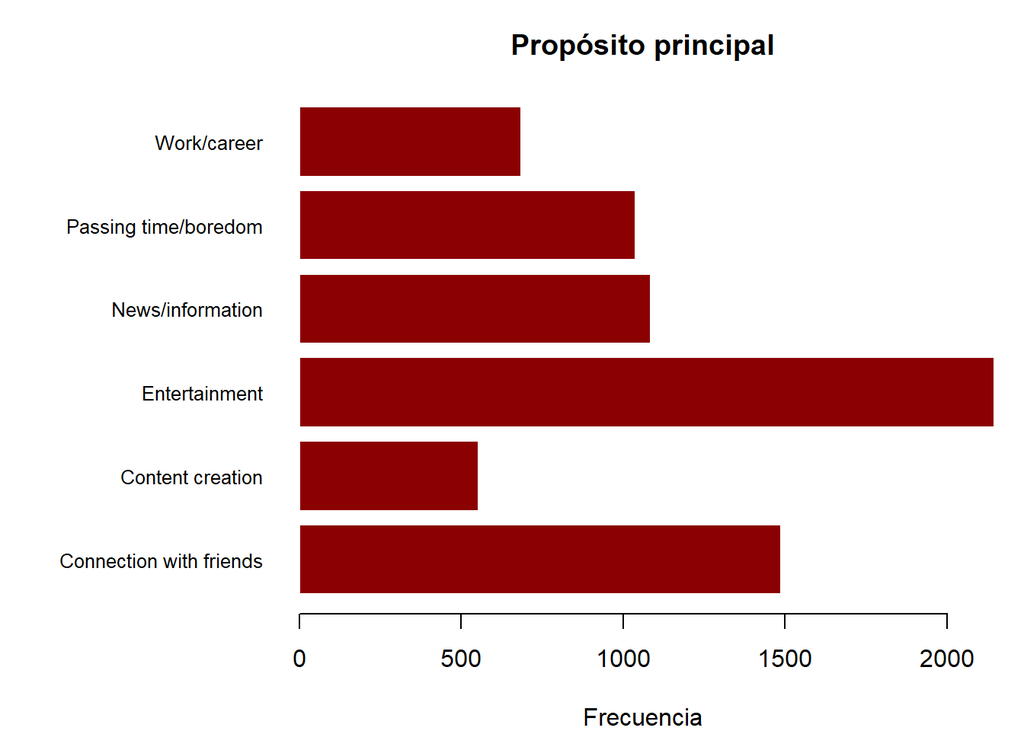

```r
op <- par(mar = c(4, 10, 3, 1))
barplot(table(datos$primary_purpose), horiz = TRUE, las = 1,
        main = "Propósito principal", xlab = "Frecuencia",
        col = "darkred", border = "white", cex.names = 0.8)
```

```r
par(op)
```

### 3.3.7 Límites de tiempo en pantalla (`uses_screen_time_limits`)

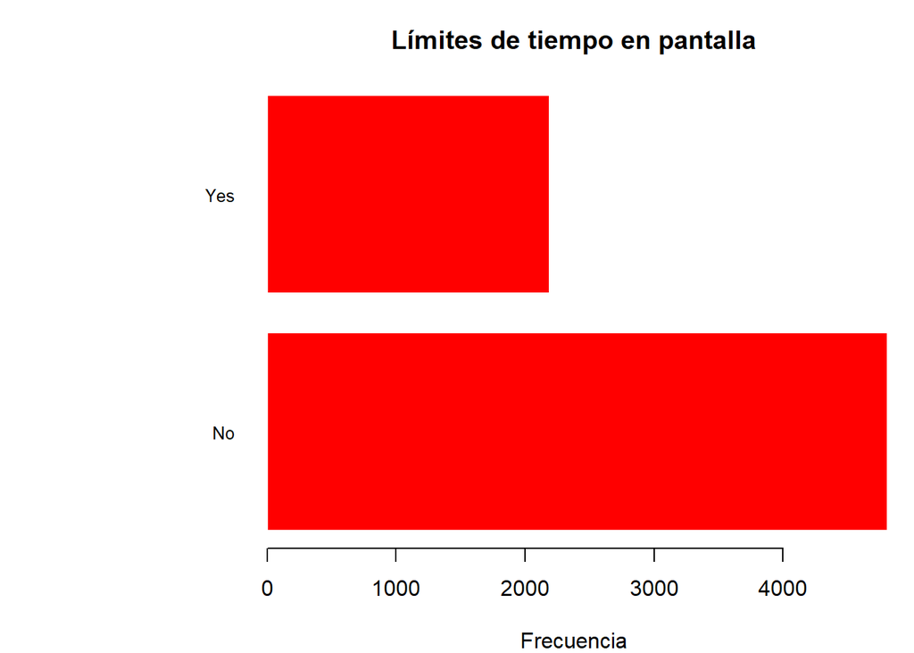

```r
op <- par(mar = c(4, 10, 3, 1))
barplot(table(datos$uses_screen_time_limits), horiz = TRUE, las = 1,
        main = "Límites de tiempo en pantalla", xlab = "Frecuencia",
        col = "red", border = "white", cex.names = 0.8)
```

```r
par(op)
```

### 3.3.8 Intento de detox digital (`attempted_digital_detox`)

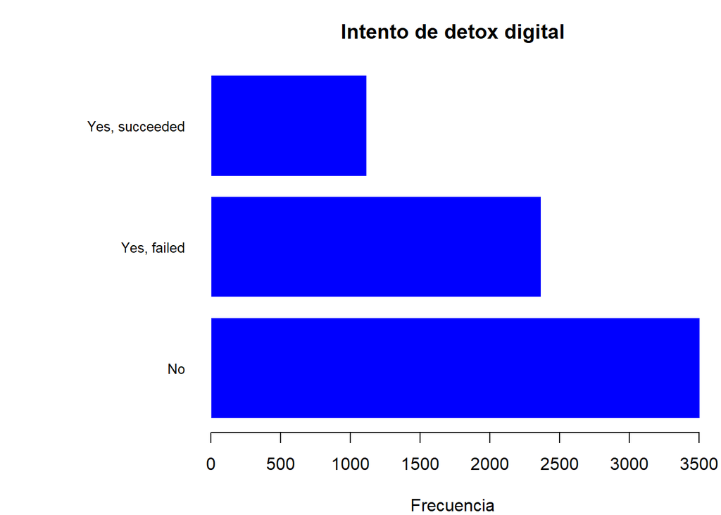

```r
op <- par(mar = c(4, 10, 3, 1))
barplot(table(datos$attempted_digital_detox), horiz = TRUE, las = 1,
        main = "Intento de detox digital", xlab = "Frecuencia",
        col = "blue", border = "white", cex.names = 0.8)
```

```r
par(op)
```

### 3.3.9 Búsqueda de apoyo psicológico (`seeks_mental_health_support`)

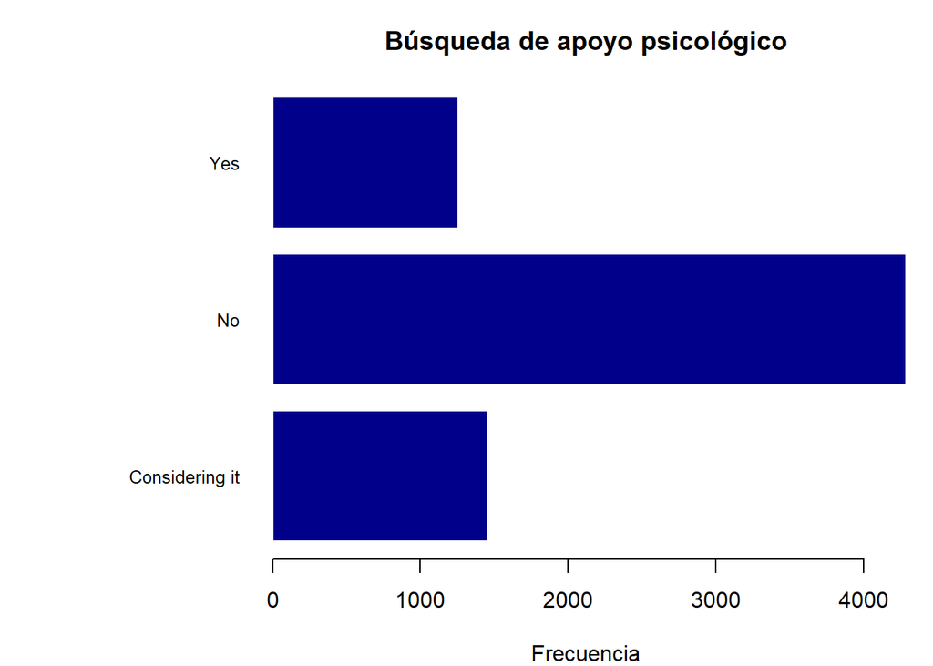

```r
op <- par(mar = c(4, 10, 3, 1))
barplot(table(datos$seeks_mental_health_support), horiz = TRUE, las = 1,
        main = "Búsqueda de apoyo psicológico", xlab = "Frecuencia",
        col = "darkblue", border = "white", cex.names = 0.8)
```

```r
par(op)
```

### 3.3.10 Banda de bienestar (`wellbeing_band`)

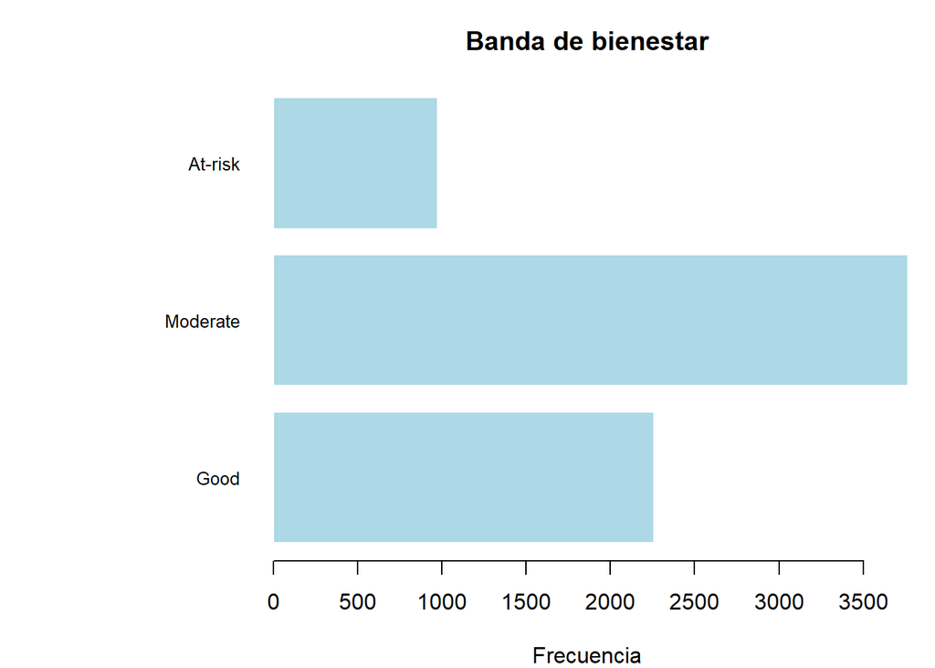

```r
op <- par(mar = c(4, 10, 3, 1))
barplot(table(datos$wellbeing_band), horiz = TRUE, las = 1,
        main = "Banda de bienestar", xlab = "Frecuencia",
        col = "lightblue", border = "white", cex.names = 0.8)
```

```r
par(op)
```

> **Describir:** el **género** está repartido casi por mitades entre femenino (3240) y masculino (3261), con una minoría no binaria (276) y 223 que prefirieron no responder (los 70 que recodificamos más los 153 originales). En **ocupación** dominan estudiantes (2715) y empleados a tiempo completo (2285). Por **región**, la muestra se concentra en Asia (1959), Norteamérica (1842) y Europa (1834), con Oceanía como el grupo más pequeño (270).

> En cuanto al uso, **TikTok** (1733) e **Instagram** (1703) son las plataformas más usadas, seguidas de **YouTube** (1264). La mayoría usa el celular de noche solo a veces (2616) o con frecuencia (2086). El **propósito principal** es el entretenimiento, y llama la atención que 4811 participantes (69%) **no** usan límites de tiempo en pantalla, mientras 2369 intentaron un detox digital y fracasaron frente a 1122 que lo lograron.

> **Analizar:** hay dos cosas que van a importar más adelante.
> - **Las bandas de bienestar están desbalanceadas.** La mayoría cae en “Moderate” (3766), seguida de “Good” (2260), y solo 974 en “At-risk”. **Decisión:** cualquier procedimiento que divida la muestra por banda de bienestar va a trabajar con un grupo minoritario de menos de mil casos, y hay que tenerlo presente antes de sacar conclusiones sobre “At-risk”.
> - **El género está equilibrado en sus dos categorías principales, pero no en las minoritarias.** “Non-binary” (276) y “Prefer not to say” (223) son grupos pequeños. **Para el informe:** sirven para describir la muestra, pero no para comparar promedios entre ellos.

> Y un dato que dice bastante de los participantes: **siete de cada diez no usan ningún límite de tiempo en pantalla**. El uso intensivo que vamos a analizar ocurre, en su mayoría, sin ninguna barrera autoimpuesta.

# 4 Análisis bivariado

## 4.1 Matriz de correlaciones

Abrimos el análisis bivariado con la **matriz de correlaciones** en lugar de ir par por par. La razón es aritmética: con 14 variables hay **91 pares posibles** (14·13/2), y examinarlos uno a uno es inabarcable. La matriz los resume todos en una sola imagen y deja ver la **estructura del conjunto** (qué variables se mueven juntas y cuáles son independientes) antes de entrar en detalle.

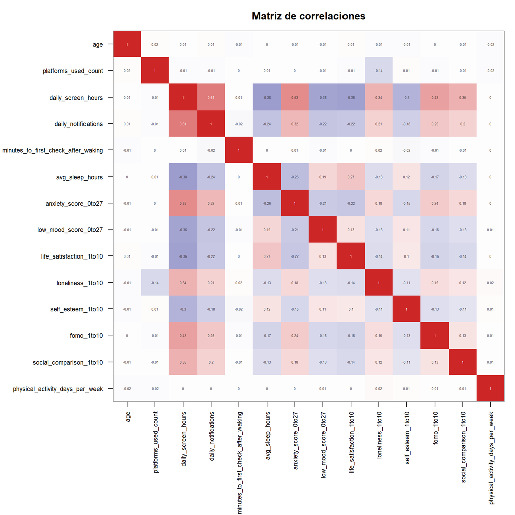

```r
cm  <- cor(num)
pal <- colorRampPalette(c("navy", "white", "firebrick3"))(200)

op <- par(mar = c(11, 11, 3, 1))
image(1:ncol(cm), 1:ncol(cm), cm, col = pal, zlim = c(-1, 1), axes = FALSE,
      xlim = c(0.5, ncol(cm) + 0.5), ylim = c(ncol(cm) + 0.5, 0.5),
      xlab = "", ylab = "", main = "Matriz de correlaciones")
axis(1, at = 1:ncol(cm), labels = colnames(cm), las = 2, cex.axis = 0.72)
axis(2, at = 1:ncol(cm), labels = colnames(cm), las = 2, cex.axis = 0.72)
for (i in 1:ncol(cm)) for (j in 1:nrow(cm)) {
  text(i, j, round(cm[i, j], 2), cex = 0.42,
       col = ifelse(abs(cm[i, j]) > 0.55, "white", "grey25"))
}
box(col = "grey60")
```

```r
par(op)
```

> **Describir:** la matriz está **mayoritariamente pálida**. De las 91 casillas, la gran mayoría están cerca del blanco, es decir, cerca de cero. Solo se encienden unas pocas.

> **Analizar:** eso ya es un hallazgo, y no el que uno esperaría. **No estamos ante un conjunto donde todo se relacione con todo**, sino ante una estructura con unos pocos vínculos fuertes y mucho ruido de fondo. **Decisión:** no podemos resumir esto variable por variable; hay que encontrar cuáles son esos pocos vínculos.

Para cuantificarlo, extraemos los pares que superan un umbral:

```r
c0 <- cm
c0[upper.tri(c0, diag = TRUE)] <- 0
idx <- which(abs(c0) >= 0.30, arr.ind = TRUE)
o <- order(abs(c0[idx]), decreasing = TRUE)
data.frame(variable_1 = colnames(num)[idx[o, 1]],
           variable_2 = colnames(num)[idx[o, 2]],
           r = round(c0[idx[o, ]], 3))
```

| variable_1 | variable_2 | r |
| --- | --- | --- |
| daily_notifications | daily_screen_hours | 0.606 |
| anxiety_score_0to27 | daily_screen_hours | 0.526 |
| fomo_1to10 | daily_screen_hours | 0.432 |
| avg_sleep_hours | daily_screen_hours | -0.380 |
| life_satisfaction_1to10 | daily_screen_hours | -0.363 |
| low_mood_score_0to27 | daily_screen_hours | -0.358 |
| social_comparison_1to10 | daily_screen_hours | 0.351 |
| loneliness_1to10 | daily_screen_hours | 0.341 |
| anxiety_score_0to27 | daily_notifications | 0.324 |

> **Describir:** solo **nueve de los 91 pares** (el 10%) superan |r| = 0,30. Y de esos nueve, **ocho involucran a `daily_screen_hours`**; la única excepción es ansiedad con notificaciones (0,32).

> Tres veces menor. El tiempo de pantalla no es una variable más de la matriz: es **el nexo que la organiza**.

> **Y también importa lo que no correlaciona.** La edad (0,007), los minutos hasta revisar el celular al despertar (0,010), la actividad física (0,004) y el número de plataformas (−0,013) son **ruido puro**. Son cuatro de las explicaciones más intuitivas del uso problemático (que sea cosa de los jóvenes, de la inmediatez al despertar, del sedentarismo o de tener muchas redes) y **ninguna se sostiene**. **Para el informe:** eso acota el problema a las variables psicológicas, que son las únicas que concentran las asociaciones.

## 4.2 Comparación de dos variables

Con el mapa general a la vista, pasamos al detalle: **los nueve pares que superan |r| = 0,30**. No vamos a revisar los 91 (sería repetir lo que la matriz ya dijo). Vamos a los que importan, y en cada uno la pregunta es la misma: **¿la relación es real, o la sostienen unos pocos casos?**

### 4.2.1 1. `daily_screen_hours` vs `daily_notifications`

```r
library(ggplot2)
library(patchwork)

g1 <- ggplot(completar_datos,
             aes(x = daily_screen_hours, y = daily_notifications)) +
  geom_point(alpha = 0.12, color = "steelblue") +
  geom_smooth(method = "lm", color = "firebrick", se = TRUE) +
  labs(title = "Notificaciones diarias según horas de pantalla",
       x = "Horas diarias de pantalla", y = "Notificaciones diarias")

# Traducción a puntos: cuartil bajo vs cuartil alto
q <- quantile(completar_datos$daily_screen_hours, c(.25, .75))
bajo <- completar_datos$daily_notifications[completar_datos$daily_screen_hours <= q[1]]
alto <- completar_datos$daily_notifications[completar_datos$daily_screen_hours >= q[2]]
c(q1_horas = round(q[1], 2), q3_horas = round(q[3], 2),
  notif_q1 = round(mean(bajo), 1), notif_q3 = round(mean(alto), 1),
  diferencia = round(mean(alto) - mean(bajo), 1))
```

```
#> q1_horas.25%  q3_horas.NA     notif_q1     notif_q3   diferencia
#>          1.9           NA         25.1        106.6         81.5
```

```r
# Correlaciones
c(pearson  = round(cor(completar_datos$daily_screen_hours,
                       completar_datos$daily_notifications), 3),
  spearman = round(cor(completar_datos$daily_screen_hours,
                       completar_datos$daily_notifications,
                       method = "spearman"), 3))
```

```
#>  pearson spearman
#>    0.606    0.648
```

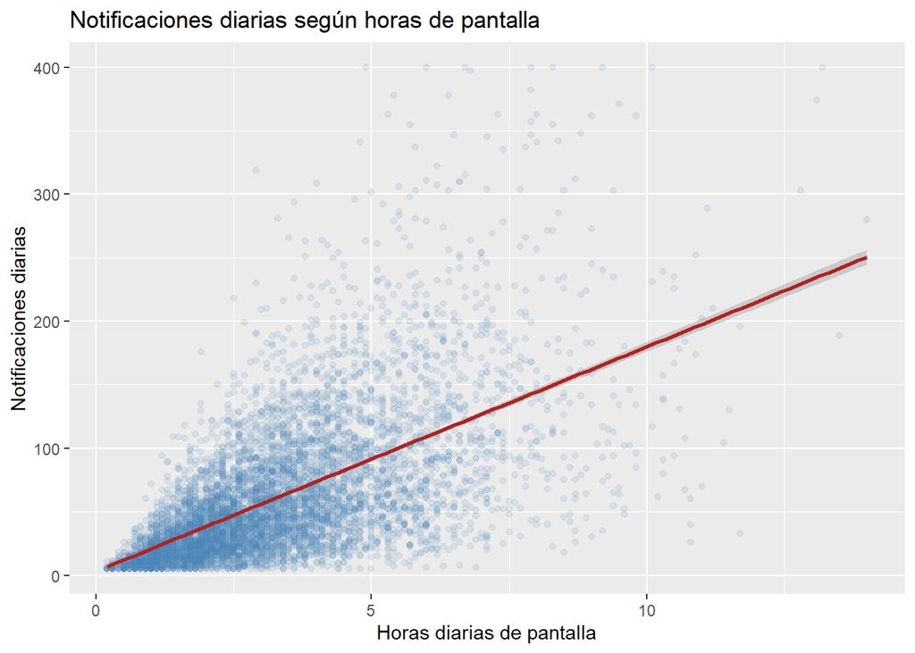

```r
g1
```

> **Analizar:** dos cosas.
> - **El número resume bien lo que se ve.** La elipse no tiene curva ni manchas aparte, así que la relación es lineal y la correlación de Pearson la describe bien. Si la nube hubiera sido una curva, ese 0,61 nos habría engañado.
> - **Son dos caras del mismo fenómeno.** Quien pasa más horas frente a la pantalla recibe más notificaciones, y quien recibe más notificaciones pasa más horas frente a la pantalla. Las dos variables miden aspectos del mismo comportamiento: la duración total y la frecuencia de interrupción.

> **Para el informe:** dejarlas ambas, pero sabiendo que apuntan a lo mismo desde dos ángulos. Cuando lleguemos a los componentes principales, esa redundancia va a importar.

### 4.2.2 2. `daily_screen_hours` vs `anxiety_score_0to27`

```r
g2 <- ggplot(completar_datos,
             aes(x = daily_screen_hours, y = anxiety_score_0to27)) +
  geom_point(alpha = 0.12, color = "steelblue") +
  geom_smooth(method = "lm", color = "firebrick", se = TRUE) +
  labs(title = "Ansiedad según horas de pantalla",
       x = "Horas diarias de pantalla", y = "Puntaje de ansiedad (0-27)")

q <- quantile(completar_datos$daily_screen_hours, c(.25, .75))
bajo <- completar_datos$anxiety_score_0to27[completar_datos$daily_screen_hours <= q[1]]
alto <- completar_datos$anxiety_score_0to27[completar_datos$daily_screen_hours >= q[2]]
c(anx_q1 = round(mean(bajo), 2), anx_q3 = round(mean(alto), 2),
  dif_puntos = round(mean(alto) - mean(bajo), 2))
```

```
#>     anx_q1     anx_q3 dif_puntos
#>       8.69      14.84       6.15
```

```r
c(pearson  = round(cor(completar_datos$daily_screen_hours,
                       completar_datos$anxiety_score_0to27), 3),
  spearman = round(cor(completar_datos$daily_screen_hours,
                       completar_datos$anxiety_score_0to27,
                       method = "spearman"), 3))
```

```
#>  pearson spearman
#>    0.526    0.492
```

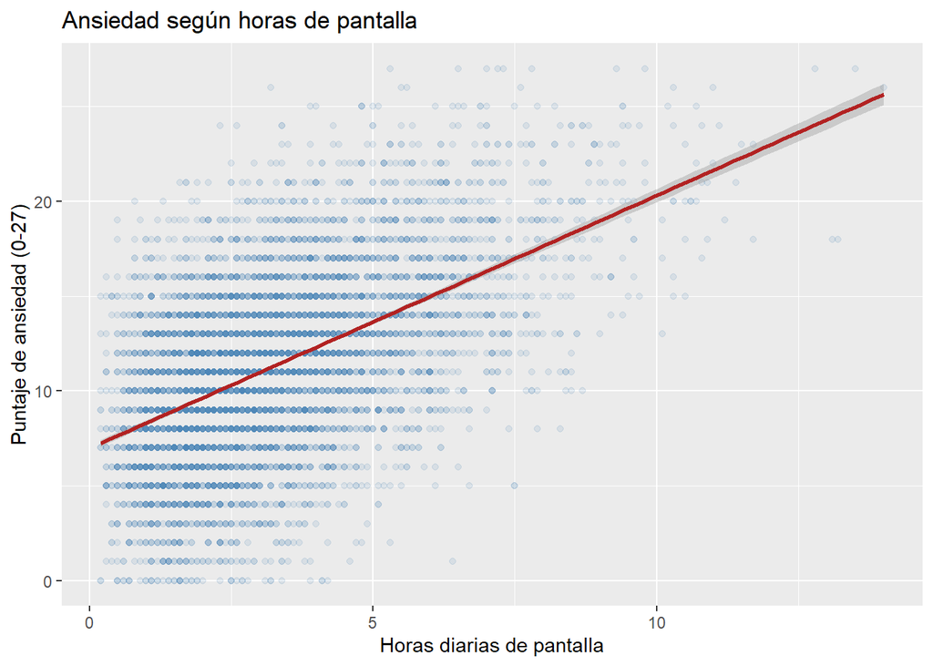

```r
g2
```

> **Describir:** la nube es alargada y lineal. Entre el cuartil bajo y el alto de pantalla hay 6,15 puntos de diferencia en ansiedad. La correlación es 0,53.

> **Analizar:** la diferencia de 6 puntos sobre una escala de 27 no es un detalle: separa a alguien con ansiedad moderada de alguien con ansiedad alta. Y sobre el mecanismo hay dos lecturas posibles, **y con estos datos no podemos elegir entre ellas**: puede ser que la pantalla genere ansiedad (por comparación, sobreestimulación, FOMO) o que la persona ansiosa busque la pantalla para calmarse.

> **Para el informe:** es la advertencia de siempre, pero aquí pesa más que en ningún otro par. Con una sola medición por participante, la dirección de la relación es indistinguible. Lo único que podemos afirmar es que **estas dos variables no aparecen la una sin la otra**.

### 4.2.3 3. `fomo_1to10` vs `daily_screen_hours`

```r
g4 <- ggplot(completar_datos,
       aes(x = factor(fomo_1to10), y = daily_screen_hours)) +
  geom_boxplot(fill = "lightblue", outlier.alpha = 0.15) +
  labs(title = "Horas de pantalla según nivel de FOMO",
       x = "FOMO (1-10)", y = "Horas diarias de pantalla")

q <- quantile(completar_datos$daily_screen_hours, c(.25, .75))
bajo <- completar_datos$fomo_1to10[completar_datos$daily_screen_hours <= q[1]]
alto <- completar_datos$fomo_1to10[completar_datos$daily_screen_hours >= q[2]]
c(fomo_q1 = round(mean(bajo), 2), fomo_q3 = round(mean(alto), 2),
  dif_puntos = round(mean(alto) - mean(bajo), 2))
```

```
#>    fomo_q1    fomo_q3 dif_puntos
#>       3.69       5.95       2.26
```

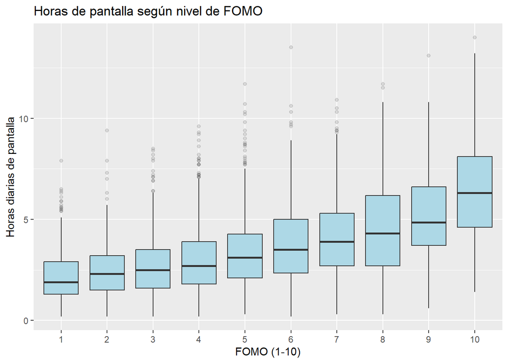

```r
g4
```

> **Describir:** el FOMO solo toma diez valores enteros, así que en lugar de una nube conviene graficar las cajas de cada nivel. Las medianas de horas de pantalla suben de forma escalonada con el nivel de FOMO. Entre el cuartil bajo y el alto hay 2,26 puntos de diferencia.

> **Analizar:** el patrón es **monótono**: sube con cada nivel, sin saltos ni retrocesos, y las cajas de los extremos apenas se tocan. Con diez niveles, una escalera así no se produce por casualidad. Eso es lo que hace creíble la tendencia.

### 4.2.4 4. `daily_screen_hours` vs `avg_sleep_hours`

```r
g3 <- ggplot(completar_datos,
             aes(x = daily_screen_hours, y = avg_sleep_hours)) +
  geom_point(alpha = 0.12, color = "steelblue") +
  geom_smooth(method = "lm", color = "firebrick", se = TRUE) +
  labs(title = "Horas de sueño según horas de pantalla",
       x = "Horas diarias de pantalla", y = "Horas de sueño promedio")

q <- quantile(completar_datos$daily_screen_hours, c(.25, .75))
bajo <- completar_datos$avg_sleep_hours[completar_datos$daily_screen_hours <= q[1]]
alto <- completar_datos$avg_sleep_hours[completar_datos$daily_screen_hours >= q[2]]
c(sueno_q1 = round(mean(bajo), 2), sueno_q3 = round(mean(alto), 2),
  dif_horas = round(mean(bajo) - mean(alto), 2))
```

```
#>  sueno_q1  sueno_q3 dif_horas
#>      7.32      6.50      0.81
```

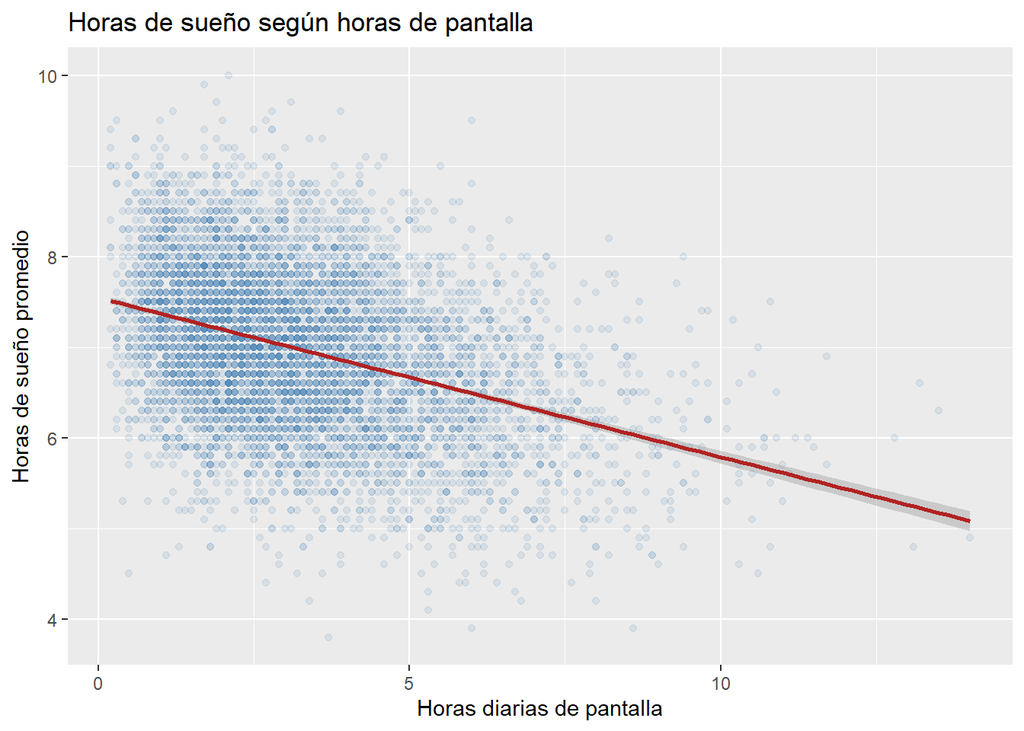

```r
g3
```

> **Describir:** la nube está inclinada hacia abajo. Entre el cuartil bajo y el alto de pantalla hay 0,81 horas de diferencia: casi una hora completa. La correlación es −0,38.

> **Analizar:** una hora menos de sueño no es un detalle estadístico: es la diferencia entre un descanso adecuado y una deuda que se acumula. Es, además, la asociación negativa más fuerte del dataset.

> Sobre el mecanismo hay dos explicaciones que la literatura sostiene y que estos datos no pueden separar: la pantalla **ocupa tiempo** que antes era de sueño, y la luz y la estimulación **retrasan** la conciliación. **Para el informe:** las dos apuntan en la misma dirección, así que no cambian la conclusión, pero conviene no elegir una sin datos que la respalden.

### 4.2.5 5. `daily_screen_hours` vs `life_satisfaction_1to10`

```r
g5 <- ggplot(completar_datos,
       aes(x = factor(life_satisfaction_1to10), y = daily_screen_hours)) +
  geom_boxplot(fill = "lightgreen", outlier.alpha = 0.15, outlier.size = 0.8) +
  labs(title = "Horas de pantalla según satisfacción con la vida",
       x = "Satisfacción con la vida (1-10)", y = "Horas diarias de pantalla") +
  theme_minimal(base_size = 13)

q <- quantile(completar_datos$daily_screen_hours, c(.25, .75))
bajo <- completar_datos$life_satisfaction_1to10[completar_datos$daily_screen_hours <= q[1]]
alto <- completar_datos$life_satisfaction_1to10[completar_datos$daily_screen_hours >= q[2]]
c(sat_q1 = round(mean(bajo), 2), sat_q3 = round(mean(alto), 2),
  dif_puntos = round(mean(bajo) - mean(alto), 2))
```

```
#>     sat_q1     sat_q3 dif_puntos
#>       7.54       6.15       1.39
```

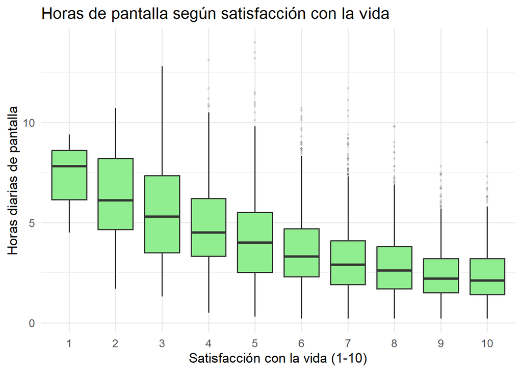

```r
g5
```

> **Analizar:** la tendencia existe y va siempre en la misma dirección, pero **el solapamiento importa**: no podemos decir que el nivel de satisfacción permita adivinar cuántas horas usa alguien. Y sobre el mecanismo, la lectura más razonable (aunque no la única) es que el tiempo de pantalla **desplaza actividades que sí construyen satisfacción**: relaciones cara a cara, descanso, actividad física. No es que la pantalla cause insatisfacción directamente; es que ocupa el lugar de lo que sí la produce.

> **Para el informe:** eso es una hipótesis, no un resultado. Pero encaja con lo que acabamos de ver en el sueño.

### 4.2.6 6. `daily_screen_hours` vs `low_mood_score_0to27`

```r
g6 <- ggplot(completar_datos,
       aes(x = factor(low_mood_score_0to27), y = daily_screen_hours)) +
  geom_boxplot(fill = "lightyellow", outlier.alpha = 0.15, outlier.size = 0.8) +
  labs(title = "Horas de pantalla según puntaje de ánimo bajo",
       x = "Ánimo bajo (0-27)", y = "Horas diarias de pantalla") +
  theme_minimal(base_size = 13) +
  theme(axis.text.x = element_text(size = 8))

c(pearson  = round(cor(completar_datos$daily_screen_hours,
                       completar_datos$low_mood_score_0to27), 3),
  spearman = round(cor(completar_datos$daily_screen_hours,
                       completar_datos$low_mood_score_0to27,
                       method = "spearman"), 3))
```

```
#>  pearson spearman
#>   -0.358   -0.368
```

```r
q <- quantile(completar_datos$daily_screen_hours, c(.25, .75))
bajo <- completar_datos$low_mood_score_0to27[completar_datos$daily_screen_hours <= q[1]]
alto <- completar_datos$low_mood_score_0to27[completar_datos$daily_screen_hours >= q[2]]
c(mood_q1 = round(mean(bajo), 2), mood_q3 = round(mean(alto), 2),
  dif_puntos = round(mean(alto) - mean(bajo), 2))
```

```
#>    mood_q1    mood_q3 dif_puntos
#>       5.34       2.09      -3.25
```

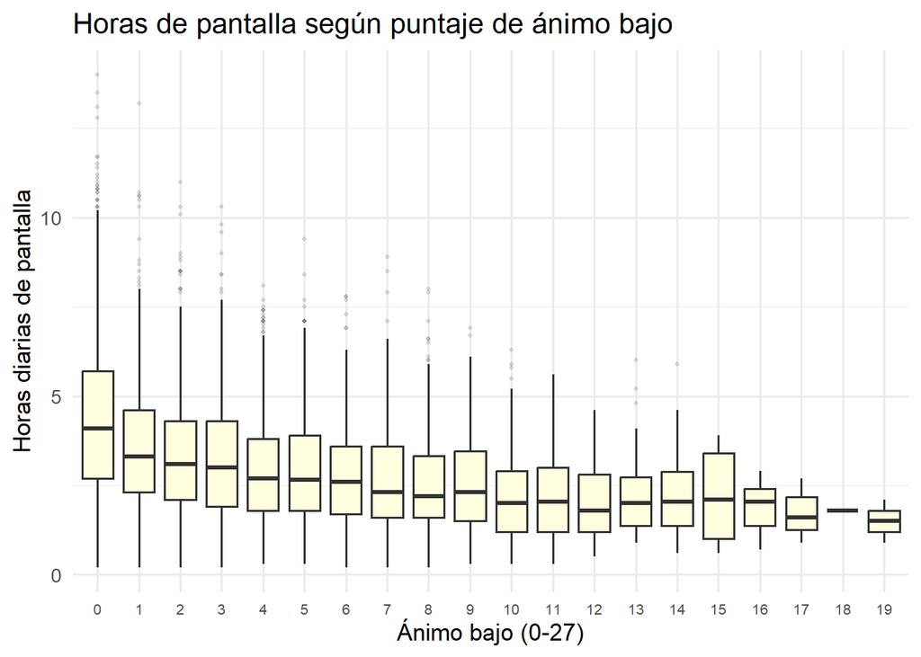

```r
g6
```

> **Describir:** el `n` se concentra en los puntajes bajos (0 a 5) y los puntajes altos tienen pocos casos. Las medianas de horas de pantalla **bajan** con el ánimo bajo: ≈4 h en puntaje 0, ≈1,5 h en puntaje 19. Correlación −0,36.

> **Analizar:** aquí está la anomalía más interesante del proyecto. Este patrón va **al revés** de todo lo anterior: en ansiedad y FOMO, más malestar venía con más pantalla; aquí, quien reporta **más** síntomas de ánimo bajo usa **menos** el celular.

> Y hay que leerlo con cuidado, por la escala: la media de ánimo bajo es 3,84 sobre 27 y un cuarto de la muestra está en 0. Los puntajes altos son casos raros, así que las medianas de esos grupos se apoyan en pocas observaciones.

> **Para el informe:** la interpretación más razonable es que **ansiedad y ánimo bajo actúan en direcciones contrarias** sobre el uso del celular: la ansiedad pega a la persona a la pantalla, mientras que el ánimo bajo le quita el interés, incluso por las redes. Encaja con que la correlación entre ansiedad y ánimo bajo sea de −0,21, que ya nos había llamado la atención en la matriz.

### 4.2.7 7. `social_comparison_1to10` vs `daily_screen_hours`

```r
g7 <- ggplot(completar_datos,
       aes(x = factor(round(daily_screen_hours)), y = social_comparison_1to10)) +
  geom_boxplot(fill = "thistle", outlier.alpha = 0.15, outlier.size = 0.8) +
  labs(title = "Comparación social según horas de pantalla",
       x = "Horas diarias de pantalla (redondeadas)", y = "Comparación social (1-10)") +
  theme_minimal(base_size = 13)

q <- quantile(completar_datos$daily_screen_hours, c(.25, .75))
bajo <- completar_datos$social_comparison_1to10[completar_datos$daily_screen_hours <= q[1]]
alto <- completar_datos$social_comparison_1to10[completar_datos$daily_screen_hours >= q[2]]
c(sc_q1 = round(mean(bajo), 2), sc_q3 = round(mean(alto), 2),
  dif_puntos = round(mean(alto) - mean(bajo), 2))
```

```
#>      sc_q1      sc_q3 dif_puntos
#>       4.57       6.35       1.78
```

```r
c(pearson  = round(cor(completar_datos$daily_screen_hours,
                       completar_datos$social_comparison_1to10), 3),
  spearman = round(cor(completar_datos$daily_screen_hours,
                       completar_datos$social_comparison_1to10,
                       method = "spearman"), 3))
```

```
#>  pearson spearman
#>    0.351    0.323
```

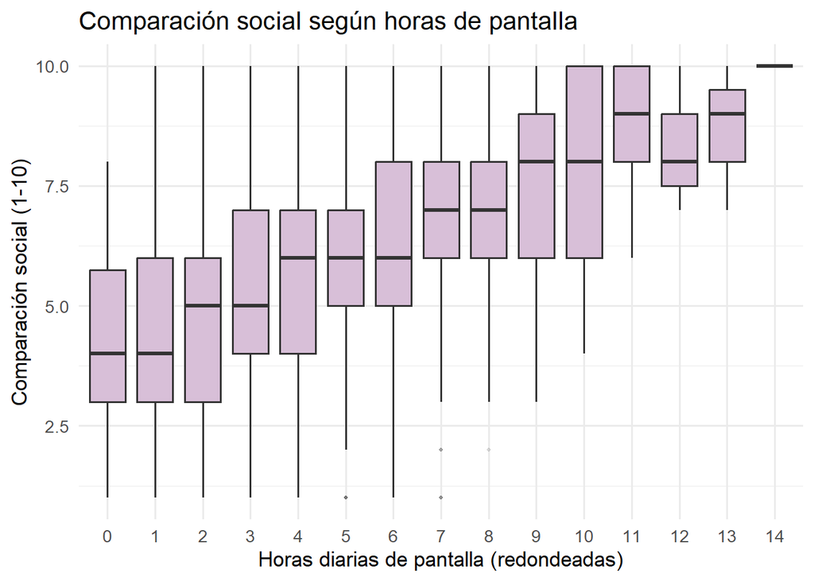

```r
g7
```

> **Analizar:** el patrón no da saltos: sube de a poco, y eso la gráfica lo muestra como cajas que se van desplazando. La lectura que mejor encaja es que pasar más tiempo en redes expone de forma constante a la vida idealizada que otros publican. No es un golpe único, es un **desgaste acumulado**: entre más contenido ajeno se consume, más se mide el propio valor en función de los demás.

> **Para el informe:** es una explicación plausible, no una prueba. Pero el efecto es moderado y el patrón es regular, así que la tendencia se sostiene.

### 4.2.8 8. `loneliness_1to10` vs `daily_screen_hours`

```r
g8 <- ggplot(completar_datos,
       aes(x = factor(round(daily_screen_hours)), y = loneliness_1to10)) +
  geom_boxplot(fill = "khaki1", outlier.alpha = 0.15, outlier.size = 0.8) +
  labs(title = "Soledad según horas de pantalla",
       x = "Horas diarias de pantalla (redondeadas)", y = "Soledad (1-10)") +
  theme_minimal(base_size = 13)

q <- quantile(completar_datos$daily_screen_hours, c(.25, .75))
bajo <- completar_datos$loneliness_1to10[completar_datos$daily_screen_hours <= q[1]]
alto <- completar_datos$loneliness_1to10[completar_datos$daily_screen_hours >= q[2]]
c(lon_q1 = round(mean(bajo), 2), lon_q3 = round(mean(alto), 2),
  dif_puntos = round(mean(alto) - mean(bajo), 2))
```

```
#>     lon_q1     lon_q3 dif_puntos
#>       3.89       5.67       1.78
```

```r
c(pearson  = round(cor(completar_datos$daily_screen_hours,
                       completar_datos$loneliness_1to10), 3),
  spearman = round(cor(completar_datos$daily_screen_hours,
                       completar_datos$loneliness_1to10,
                       method = "spearman"), 3))
```

```
#>  pearson spearman
#>    0.341    0.315
```

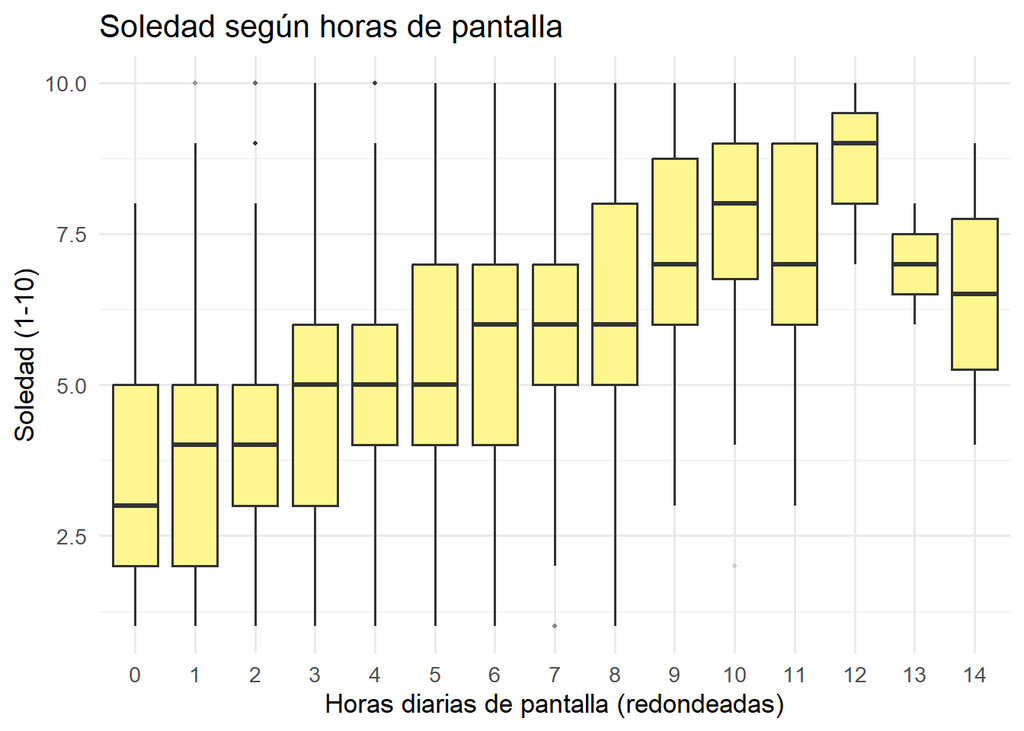

```r
g8
```

> **Describir:** las cajas se desplazan hacia arriba a medida que se acumulan horas de uso. El grupo con menor tiempo de pantalla promedia 3,89 en la escala de soledad; el de mayor exposición alcanza 5,67. Aumento: +1,78 sobre 10.

> **Analizar:** el patrón es ascendente y claro, del mismo tamaño que el de comparación social.

> Y aquí hay una paradoja que vale la pena nombrar: **las redes prometen conectar y el resultado apunta a lo contrario**. La lectura más razonable es que el uso desmedido **desplaza la interacción cara a cara** por un consumo pasivo. La pantalla calma momentáneamente la sensación de desconexión, pero no la resuelve, y a la larga la acentúa.

> **Para el informe:** es una hipótesis, igual que antes. Pero conviene mirar un número que la respalda: la soledad correlaciona **más fuerte con las horas de pantalla** (0,34) que **con la comparación social** (0,11), que sería lo esperable si las redes conectaran de verdad.

### 4.2.9 9. `anxiety_score_0to27` vs `daily_notifications`

```r
g9 <- ggplot(completar_datos,
             aes(x = daily_notifications, y = anxiety_score_0to27)) +
  geom_point(alpha = 0.12, color = "steelblue") +
  geom_smooth(method = "lm", color = "firebrick", se = TRUE) +
  labs(title = "Ansiedad según notificaciones diarias",
       x = "Notificaciones diarias", y = "Puntaje de ansiedad (0-27)") +
  theme_minimal(base_size = 13)

q_notif <- quantile(completar_datos$daily_notifications, c(.25, .75))
bajo_notif <- completar_datos$anxiety_score_0to27[completar_datos$daily_notifications <= q_notif[1]]
alto_notif <- completar_datos$anxiety_score_0to27[completar_datos$daily_notifications >= q_notif[2]]
c(anx_notif_q1 = round(mean(bajo_notif), 2), anx_notif_q3 = round(mean(alto_notif), 2),
  dif_puntos = round(mean(alto_notif) - mean(bajo_notif), 2))
```

```
#> anx_notif_q1 anx_notif_q3   dif_puntos
#>         9.44        13.57         4.13
```

```r
c(pearson  = round(cor(completar_datos$daily_notifications,
                       completar_datos$anxiety_score_0to27), 3),
  spearman = round(cor(completar_datos$daily_notifications,
                       completar_datos$anxiety_score_0to27,
                       method = "spearman"), 3))
```

```
#>  pearson spearman
#>    0.324    0.326
```

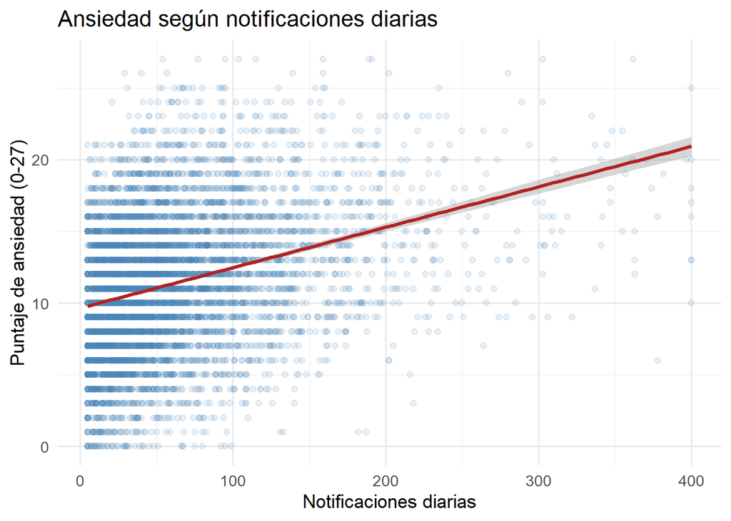

```r
g9
```

> **Describir:** a diferencia de los pares anteriores, aquí no se comparan horas de uso sino alertas. La nube es positiva y continua. Quienes reciben pocas notificaciones (≤20) promedian 9,44 puntos de ansiedad; quienes reciben muchas (≥83), 13,57. Salto: +4,13 sobre 27.

> **Analizar:** este es **el único par destacado que no involucra las horas de pantalla**, y por eso es el más informativo de los nueve. Revela algo que los otros no podían mostrar: **el problema no es solo cuánto tiempo se usa el celular, sino cuántas veces interrumpe**.

> El mecanismo que encaja es que cada notificación genera un microestímulo de alerta o expectativa que rompe la concentración y mantiene al cerebro en un estado de hipervigilancia. **Para el informe:** eso tiene una consecuencia práctica interesante. Si el mecanismo fuera solo la duración, bastaría con usar menos horas; si cuenta la frecuencia de interrupción, **el modo de uso importa tanto como la cantidad**.

# 5 La puerta a lo multivariado

Con todo lo que llevamos, quedan tres preguntas abiertas, y cada una es una unidad del resto del curso:

| Lo que vimos | La pregunta que queda | Con qué se responde |
| --- | --- | --- |
| Revisamos los datos **variable por variable** | ¿Hay participantes raros **en la combinación**, aunque ninguna medición por separado sea extrema? | Distancia de Mahalanobis |
| Las variables de pantalla **se mueven con las psicológicas** | ¿Hay **una sola dimensión** detrás de todas? ¿O varias? | Componentes principales |
| `daily_screen_hours` **se conecta con casi todo** | ¿Se pueden **separar perfiles** de participantes con esas relaciones? | Análisis de conglomerados |

Y ya tenemos una pista de por dónde va a empezar esa fase:

```r
m  <- colMeans(num)
S  <- cov(num)
d2 <- mahalanobis(num, m, S)
sum(d2 > qchisq(0.999, ncol(num)))
```

```
#> [1] 69
```

**69 observaciones** superan el umbral, cuando bajo normalidad se esperarían unas 7. Es decir: hay participantes que son raros **en la combinación** de sus variables aunque, una por una, ninguna de sus mediciones sea extrema. Esa es exactamente la primera pregunta de la tabla, y ya asoma.

# 6 Conclusión

No aprendimos ninguna técnica nueva: usamos las del primer corte, todas juntas, sobre un solo problema. Lo que quedó claro es **para qué sirve cada una**:

- **Revisar la calidad** sirvió para descubrir que los 175 `NA` eran en realidad 173 filas, y para decidir con criterio en lugar de por costumbre.
- **Mirar cada variable** sirvió para saber cuáles se comportan como se espera y cuáles no, y para entender que el promedio no siempre representa a nadie.
- **Mirar las variables juntas** sirvió para encontrar que el tiempo de pantalla es el nexo de toda la matriz, y que cuatro de las explicaciones más intuitivas no se sostienen.
- **Comparar los pares** sirvió para ver la relación por dentro: dónde es lineal, qué la sostiene, y dónde las direcciones se contradicen.

Lo que sigue es dejar de preguntar por pares y preguntar por la **combinación completa**. Eso es el análisis multivariado.